# Analiza cen biletów lotniczych na wybranych trasach europejskich

Piotr Otręba

2024-12-06

```r
library(tidyverse)
library(psych)
library(ggplot2)
library(readxl)
library(stringr)
library(tidyr)
library(knitr)
```

# Wstęp

Analiza obejmuje dane dotyczące cen biletów lotniczych na kilku wybranych trasach w Europie. Miastami początkowymi były Kraków i Warszawa, natomiast destynacje to: Londyn, Paryż, Rzym, Berlin. W zbiorze danych występują loty bezpośrednie, jak i takie z przesiadkami. Ja jednak zajmę się analizą wyłącznie połączeń bezpośrednich oraz tych z 1 przesiadką. Dane zostały zeskrapowane ze strony momondo.pl.

W dalszej części analizy będę używał słowa *segment*. Oznacza ono podróż z lotniska początkowego do docelowego, niezależnie od liczby przesiadek.

Głównym celem badania jest ustalenie czynników wpływających na cenę biletu lotniczego.

# Część 1. Wczytanie danych i preprocessing.

```r
dane <- read_excel("momondo_projekt/Wszystkie_loty.xlsx")
dim(dane)
```

```
## [1] 353466     18
```

Jest ponad 353 tys. obserwacji w 18 kolumnach.

Z kolumny `Layovers (if any)` wyciągam 3-literowy kod lotniska przesiadkowego oraz czas przesiadki.

```r
dane$layover_airport <- str_extract(dane$`Layovers (if any)`,
                                     regex("[A-Z]{3}",
                                    ignore_case = FALSE))
godziny <- str_extract(
dane$`Layovers (if any)`,
# 1 lub więcej wystąpienie cyfry, po którym bezpośrednio następuje spacja i litera h
regex("\\d+(?=\\sh)",
      ignore_case = F))

minuty <- str_extract(dane$`Layovers (if any)`,
                      # 1 lub więcej wystąpienie cyfry, przed którym bezpośrednio występuje spacja
                      regex("(?<=h\\s)\\d+",
                      ignore_case = FALSE))

dane$layover_duration <- as.numeric(godziny) + as.numeric(minuty)/60


# Usuwam już niepotrzebną kolumnę.
dane <- subset(dane, select = -`Layovers (if any)`)
```

Wstępnie pozostawię wszystkie loty bezpośrednie oraz te z 1 przesiadką.

```r
dane <- dane[dane$`#Layovers` %in% 0:1,]
dane$layover_airport <- replace_na(dane$layover_airport, "-")
dane$layover_duration <- replace_na(dane$layover_duration, 0)
```

Sprawdzam, czy występują wartości brakujące.

```r
sapply(dane, function(x) {sum(is.na(x))}) %>% kable()
```

|  | x |
| --- | --- |
| Extraction_date | 0 |
| Airline | 0 |
| Flight_weekday | 0 |
| Flight_date | 0 |
| Departure_time | 0 |
| Arrival_time | 0 |
| Flight_time | 0 |
| Departure_airport_code | 215 |
| Depparture_airport_name | 215 |
| Destination_airport_code | 215 |
| Destination_airport_name | 215 |
| Price [PLN] | 215 |
| #Layovers | 0 |
| Ticket_class | 0 |
| Cabin_bag | 0 |
| Checked_bag | 127 |
| Days_to_departure | 0 |
| layover_airport | 0 |
| layover_duration | 0 |

W zbiorze danych występują braki. Usuwam te obserwacje. Pozostawiam też jedynie unikatowe wiersze. Istotna uwaga: przeprowadzając wstępną inspekcję danych, zauważyłem, że występują obserwacje nieznacznie różniące się jedynie ceną i linią lotniczą, dotyczą jednak tego samego lotu w tym samym dniu. Może to wynikać z tego, że na stronie momondo widnieją oferty z bardzo podobną ceną na ten sam lot, różni się jedynie pośrednik, na którego stronie kupujemy bilet. Ponadto, tradycyjne linie lotnicze często należą do sojuszy (np. Star Alliance), wtedy zdarza się, że np. bilet na lot wykonany przez Lufthansę można kupić na stronie LOTu. Dlatego spośród kilku wierszy różniących się tylko ceną lub linią lotniczą pozostawię pierwszy wiersz, o najmniejszym indeksie.

```r
# usunięcie braków
dane <- dane[complete.cases(dane), ]

# usunięcie tych sanych lotów w danym dniu zebranych danego dnia, ale z różną ceną lub linią
dane <- dane %>%
  distinct(across(-c(`Price [PLN]`, Airline)), .keep_all = TRUE)
```

Z kolumny `Extraction_date` wyodrębniam dzień tygodnia, kiedy pobrano dane.

```r
dane <- as.data.frame(dane)
split_col <- as.data.frame(str_split(dane$Extraction_date, ", ", simplify = TRUE))
colnames(split_col) <- c("Extraction_Time", "Extraction_Weekday")
dane <- cbind(dane[, 1], split_col, dane[, -1])

#Usuwam pierwszą kolumnę
dane <- dane[, -1]
```

Dodaję dodatkową kolumnę `dep_city`, zawierającą informację o mieście wylotu.

```r
dane <- dane %>%
  mutate(dep_city = case_when(
    Departure_airport_code %in% c('WAW', 'WMI') ~ "Warszawa",
    Departure_airport_code == 'KRK' ~ "Kraków"
  ),
  .after = "Departure_airport_code"
)
# Sprawdzam braki w nowo utworzonej kolumnie
sum(is.na(dane$dep_city))
```

```
## [1] 0
```

W `dep_city` nie ma braków, czyli nie pominąłem żadnego z lotnisk wylotu. Analogicznie niech `arr_city` oznacza miasto przylotu.

```r
dane <- dane %>%
  mutate(arr_city = case_when(
    Destination_airport_code %in% c('LHR', 'LON', 'LTN', 'LGW', 'LCY', 'STN', 'SEN') ~ "Londyn",
    Destination_airport_code %in% c('CDG', 'PAR', 'BVA', 'ORY' ) ~ "Paryż",
    Destination_airport_code %in% c('CIA', 'FCO', 'ROM') ~ "Rzym",
    Destination_airport_code == "BER" ~ "Berlin",
  ),
  .after = "Departure_airport_code"
)

# Sprawdzam braki w nowo utworzonej kolumnie
sum(is.na(dane$arr_city))
```

```
## [1] 0
```

Nie ma wartości brakujących, co oznacza, że nie pominąłem żadnego docelowego lotniska.

W kolumnie `Airline` mamy dane o liniach lotniczych. Chcę się dowiedzieć, jakie linie operują na analizowanych trasach i ile lotów wykonały.

```r
dane %>%
  group_by(Airline) %>%
  count() %>%
  arrange(desc(n)) %>%
  head(15) %>%
  kable()
```

| Airline | n |
| --- | --- |
| Lufthansa | 48919 |
| KLM | 33083 |
| LOT | 20585 |
| Ryanair | 16041 |
| Austrian Airlines | 15332 |
| SWISS | 9770 |
| LOT, Ryanair | 8411 |
| Wizz Air, easyJet | 7965 |
| Wizz Air | 7181 |
| LOT, Lufthansa | 7117 |
| Air France | 6965 |
| LOT, Wizz Air | 6856 |
| Ryanair, easyJet | 5955 |
| British Airways | 5615 |
| Wizz Air, Vueling | 4940 |

W zbiorze danych są loty wykonywane przez easyJet Europe oraz Ryanair UK. Na potrzeby dalszej analizy warto będzie to ujednolicić.

Zamienię *easyJet Europe* na *easyJet*, podobnie *Ryanair UK* na *Ryanair* i *Wizz Air Malta* oraz *Wizz Air UK* na *Wizz Air*. Użycie funkcji `gsub` (zamiast zwykłego przypisania nowej wartości) gwarantuje, że zamiana nastąpi także w rekordach, gdzie mamy dwie nazwy linii oddzielone przecinkiem.

```r
dane$Airline <- gsub("Ryanair UK", "Ryanair", dane$Airline)
dane$Airline <- gsub("easyJet Europe", "easyJet", dane$Airline)
dane$Airline <- gsub("Wizz Air Malta", "Wizz Air", dane$Airline)
dane$Airline <- gsub("Wizz Air UK", "Wizz Air", dane$Airline)
```

Wyciągam teraz liczbę wystąpień linii lotniczych, ale rozbijam dwie linie oddzielone przecinkiem do osobnych kategorii.

```r
# Sprawdzamy, czy jest przecinek
czy_przecinek <- grepl(",", dane$Airline)

# Wyciągamy to, co przed i po przecinku
przed <- str_extract(dane$Airline[czy_przecinek], ".*(?=,)")
po <- str_extract(dane$Airline[czy_przecinek], "(?<=, ).*")

# Łączymy w jeden wektor: nazwy linii po przecinku, przed przecinkiem i te bez przecinka
linie <- c(przed, po, dane$Airline[!czy_przecinek])

linie_df <- data.frame(linia = linie)
linie_df %>%
  group_by(linia) %>%
  count() %>%
  arrange(desc(n)) %>%
  head(10) %>%
  kable()
```

| linia | n |
| --- | --- |
| Lufthansa | 56582 |
| LOT | 55114 |
| Ryanair | 49951 |
| Wizz Air | 47637 |
| KLM | 35042 |
| easyJet | 25446 |
| Austrian Airlines | 18242 |
| SWISS | 10498 |
| Vueling | 9191 |
| Air France | 9102 |

Widać, że aż ponad 56 tys. segmentów było w całości lub częściowo wykonanych przez Lufthansę. Na drugim miejscu był LOT i Ryanair. Chcę uwzględnić w analizie zarówno tradycyjne linie lotnicze, jak i te droższe. Dlatego uwzględnię 8 linii lotniczych: Lufthansa, KLM, LOT, Air France, Wizz Air, Ryanair, easyJet, British Airways.

Wybierając te linie lotnicze, kieruję się nie tylko tym, aby pozostawić jak najwięcej obserwacji, lecz także chęcią pozostawienia połączeń bezpośrednich. Dlatego uwzględniam np Air France (lata bezpośrednio do Paryża), a nie SWISS (brak lotów bezpośrednich do któregokolwiek z wybranych miast).

Tworzę dodatkowe kolumny, dzieląc `Airline` na kolumny `Airline1` i `Airline2`, zawierające nazwy linii lotniczych, które wykonały odpowiednio 1 i 2 odcinek danego segmentu. Jeśli lot jest bezpośredni, to w kolumnie `Airline2` dam “-”.

```r
linie_wektor <- c("Lufthansa", "KLM", "LOT", "Air France", "Wizz Air", "Ryanair", "easyJet", "British Airways")
dane <- dane %>%
  mutate(
    # Sprawdzamy, czy w kolumnie Airline jest przecinek
    czy_przecinek = grepl(",", Airline),

    # Pozostawiamy tylko takie połączenia, że wszystkie loty zostały wykonane przez linie z wektora linie_wektor
    Airline = case_when(
      # Jeśli jest przecinek, sprawdzamy, czy obie linie lotnicze są w wyżej zdefiniowanym wektorze
      czy_przecinek ~ ifelse(
        str_extract(Airline, ".*(?=,)") %in% linie_wektor &
        str_extract(Airline, "(?<=, ).*") %in% linie_wektor,
        Airline, NA
      ),
      # Jeśli nie ma przecinka, sprawdzamy, czy nazwa linii jest w wektorze
      !czy_przecinek ~ ifelse(Airline %in% linie_wektor, Airline, NA)
    ),

    Airline1 = ifelse(czy_przecinek, str_extract(Airline, ".*(?=,)"), Airline),
    Airline2 = case_when(
      `#Layovers` == 0 ~ "-",
      TRUE ~ ifelse(czy_przecinek, str_extract(Airline, "(?<=, ).*"), Airline)
    )

  ) %>%
  select(-czy_przecinek, -Airline)

dane <- dane[!is.na(dane$Airline1) & !is.na(dane$Airline2),]
```

Dodam jeszcze kolumny `low_cost1` i `low_cost2` określające, czy linia wykonująca odpowiednio 1 i 2 odcinek segmentu to tania (low-cost), czy tradycyjna (legacy) linia lotnicza. Jeśli lot był bezpośredni, to w kolumnie `low_cost2` dam “-”.

```r
dane <- dane %>%
  mutate(
    low_cost1 = case_when(
      Airline1 %in% c("Ryanair", "easyJet", "Wizz Air") ~ "low-cost",
      TRUE ~ "legacy"
    ),

    low_cost2 = case_when(
      Airline2 %in% c("Ryanair", "easyJet", "Wizz Air") ~ "low-cost",
      Airline2 == "-" ~ "-",
      TRUE ~ "legacy"
    )
  ) %>%
  relocate(low_cost1, .after = Airline1) %>%
  relocate(low_cost2, .after = Airline2)
```

Następnie zajmę się kolumną `Ticket class`, zawierającą informację o oferowanej taryfie.

```r
unique(dane$Ticket_class)
```

```
##  [1] "Economy Saver"            "Basic"
##  [3] "Economy Light"            "Light"
##  [5] "Ekonomiczna Standard"     "Economy Classic"
##  [7] "Biznesowa"                "Business Standard"
##  [9] "Business Saver"           "Podstawowa"
## [11] "Ekonomiczna"              "Ekonomiczna Basic"
## [13] "Standardowy"              "Ecosaver"
## [15] "Plus"                     "Mieszana"
## [17] "Standard"                 "Economy Light (+1 bagaż)"
## [19] "Light (+1 bagaż)"         "Business"
## [21] "Biznes"                   "Ekonomiczna Fully Flex"
## [23] "Biznesowa Fully Flex"     "Business Semi Flex"
## [25] "Business Leisure"         "Podstawowa (+1 bagaż)"
## [27] "Economy Saver (+1 bagaż)" "WIZZ Go"
## [29] "Basic (+1 bagaż)"         "Economy Flex"
## [31] "Business Flex"
```

Chcę ujednolicić nazwy taryf, dlatego:

- wszystkie nazwy ze słowem “Economy”, “Ekonomiczna”, “Basic” traktuję jako klasę ekonomiczną;
- ponadto jako klasę ekonomiczną traktuję klasy “Light”, “WIZZ Go”, “Plus”, “Standardowy”, “Ecosaver”;
- wszystkie klasy ze słowem “Biznes”, “Biznesowa”, “Business” traktuję jako “Biznes”.

Na lotach międzynarodowych w obrębie Europy klasa ekonomiczna premium występuje rzadko i zazwyczaj nie ma żadnej różnicy pomiędzy kabiną ekonomiczną a ekonomiczną premium (różnica tkwi w liczbie sztuk bagażu (co uwzględniam w danych) lub ewentualnie drobnym poczęstunku). Dlatego nie widzę potrzeby, aby klasę “Plus” (odpowiednik ekonomicznej premium w British Airways) klasyfikować osobno.

```r
dane <- dane %>%
  mutate(Ticket_class = case_when(
    grepl("Business", Ticket_class) ~ "Biznes",
    grepl("Biznes", Ticket_class) ~ "Biznes", # słowa typu: "Biznes", "Biznesowa"
    grepl("Bsaver", Ticket_class) ~ "Biznes",
    TRUE ~ "Ekonomiczna"
  ))

unique(dane$Ticket_class)
```

```
## [1] "Ekonomiczna" "Biznes"
```

Muszę się jeszcze zająć kolumną `Flight time`. Trzeba zamienić czas trwania lotu z formatu XX h XX min na zmienną numeryczną. Najpierw tworzę wektor z pełnymi godzinami.

```r
godziny <- str_extract(
  dane$Flight_time,
  # 1 lub więcej wystąpienie cyfry, po którym bezpośrednio następuje spacja i litera h
  regex("\\d+(?=\\sh)",
        ignore_case = F))
```

Teraz tworzę wektor z minutami, następnie łączę oba wektory w celu otrzymania czasu lotu jako zmiennej typu `numeric`.

```r
minuty <- str_extract(dane$Flight_time,
                      regex("(?<=h\\s)\\d+", # 1 lub więcej wystąpienie cyfry, przed którym bezpośrednio występuje spacja i litera h
                      ignore_case = F))

dane$Flight_time <- round(as.numeric(godziny) + as.numeric(minuty)/60, 2)
```

Podobnie, na typ `numeric` zamieniam czasy wylotu i przylotu.

```r
# Zamiana czasu wylotu
dane$Departure_time <- round(
  (as.numeric(str_extract(dane$Departure_time, regex("^\\d+"))) +
    as.numeric(str_extract(dane$Departure_time, regex("(?<=:)\\d+")))/60),
  2)

# Zamiana czasu przylotu
dane$Arrival_time <- round(
  (as.numeric(str_extract(dane$Arrival_time, regex("^\\d+"))) +
    as.numeric(str_extract(dane$Arrival_time, regex("(?<=:)\\d+")))/60),
  2)
```

Kolumnę `Flight_date` zamieniam na typ `Date`.

```r
dane$Flight_date <- as.Date(dane$Flight_date)
```

Kolumny `Extraction_Weekday` oraz `Flight_weekday` zamieniam na typ `factor`.

```r
dni_tyg <- c("Monday", "Tuesday", "Wednesday",
             "Thursday", "Friday", "Saturday", "Sunday")

dane$Extraction_Weekday <- factor(dane$Extraction_Weekday, levels = dni_tyg)
dane$Flight_weekday <- factor(dane$Flight_weekday, levels = dni_tyg)
```

### Wartości odstające

**Outliery ze względu na czas lotu.**

Sprawdzam rozkład czasu podróży w zależności od destynacji.

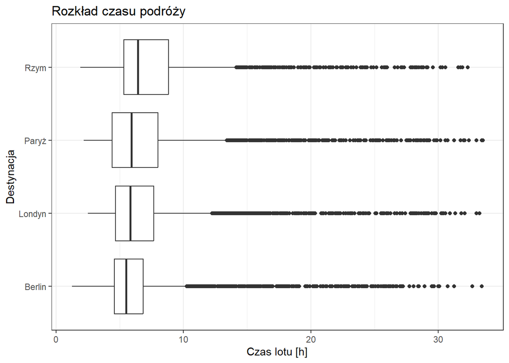

```r
dane %>%
  group_by(dep_city, arr_city) %>%
  ggplot(aes(x = Flight_time, y = arr_city)) +
  geom_boxplot() +
  labs(title = "Rozkład czasu podróży",
       x = "Czas lotu [h]",
       y = "Destynacja") +
  theme_bw()
```

Widzimy wiele outlierów - ofert, dla których łączny czas podróży jest bardzo długi, przekraczający 12h. Sprawdzam, jakie dane stanowią na powyższym wykresie pudełkowym obserwacje odstające.

```r
outliers_flight_time <- dane[dane$Flight_time >
                               (quantile(dane$Flight_time, 0.75) + 1.5 * IQR(dane$Flight_time)), ]
describe(outliers_flight_time[,c("Price [PLN]", "Flight_time")])
```

```
##             vars    n   mean     sd median trimmed    mad   min     max range
## Price [PLN]    1 6964 615.51 501.67 512.00  554.25 222.39 194.0 26991.0 26797
## Flight_time    2 6964  15.86   4.01  14.17   15.02   1.85  12.5    33.5    21
##              skew kurtosis   se
## Price [PLN] 23.06  1108.96 6.01
## Flight_time  1.85     3.04 0.05
```

Mediana czasu podróży wynosząca ponad 14h i wartość maksymalna równa 33,5h… Te obserwacje zdecydowanie trzeba odfiltrować.

Chcę jednak zastosować nietypową metodę filtrowania. Skupię się na tych obserwacjach, dla których czas lotu jest nie większy od $4.5+1.5x$, gdzie $x$ oznacza średni czas bezpośredniego lotu na danej trasie. Robię tak, ponieważ chcę analizować oferty, które nie tylko nie są outlierami w stricte statystycznym sensie, ale które również są w miarę optymalne z punktu widzenia pasażera. Warunek, który określiłem, uwzględnia (długą) przesiadkę i czas dłuższy niż dla lotu bezpośredniego na danej trasie. Jednocześnie odrzuca przesadnie długie loty, których raczej nikt by nie wybrał.

Usuwam outliery według powyższego klucza. Najpierw tworzę tabelę ze średnimi czasami lotów bezpośrednich, potem dodaję kolumnę `sredni_czas` do ramki danych.

```r
mean_direct_time <- dane %>%
  filter(`#Layovers` ==0) %>%
  group_by(dep_city, arr_city) %>%
  summarize(sredni_czas = round(mean(Flight_time), 2))

mean_direct_time %>% kable()
```

| dep_city | arr_city | sredni_czas |
| --- | --- | --- |
| Kraków | Berlin | 1.25 |
| Kraków | Londyn | 2.62 |
| Kraków | Paryż | 2.35 |
| Kraków | Rzym | 2.01 |
| Warszawa | Berlin | 1.33 |
| Warszawa | Londyn | 2.84 |
| Warszawa | Paryż | 2.57 |
| Warszawa | Rzym | 2.48 |

Teraz filtruję dane wg wcześniej określonego warunku.

```r
dane <- dane %>%
  left_join(mean_direct_time, by = c("dep_city", "arr_city")) %>%
  filter(Flight_time <= 4.5 + 1.5*sredni_czas) %>%
  select(-sredni_czas)
```

**Outliery ze względu na cenę**

```r
# Wyszukujemy outliery w obrębie grup linii lotniczych, klasy i walizki
outliery_cena <- dane %>%
  group_by(Airline1, Airline2, Ticket_class, Checked_bag) %>%
  mutate(q1 = quantile(`Price [PLN]`, 0.25),
         q3 = quantile(`Price [PLN]`, 0.75)) %>%
  ungroup() %>%
  filter((`Price [PLN]` > q3 + 1.5*(q3-q1))) %>%
  select(-q1, -q3)

dane <- dane %>%
  group_by(Destination_airport_code, Ticket_class) %>%
  mutate(q1 = quantile(`Price [PLN]`, 0.25),
         q3 = quantile(`Price [PLN]`, 0.75)) %>%
  ungroup() %>%
  filter(`Price [PLN]` <= q3 + 1.5*(q3-q1)) %>%
  select(-q1, -q3)
```

# Część 2. Analiza danych.

Sprawdzam typy danych w kolumnach.

```r
str(dane)
```

```
## tibble [144,313 × 25] (S3: tbl_df/tbl/data.frame)
##  $ Extraction_Time         : chr [1:144313] "02/11/2024 19:16" "02/11/2024 19:16" "02/11/2024 19:16" "02/11/2024 19:16" ...
##  $ Extraction_Weekday      : Factor w/ 7 levels "Monday","Tuesday",..: 6 6 6 6 6 6 6 6 6 6 ...
##  $ Flight_weekday          : Factor w/ 7 levels "Monday","Tuesday",..: 1 1 1 1 1 1 1 1 2 2 ...
##  $ Flight_date             : Date[1:144313], format: "2024-11-04" "2024-11-04" ...
##  $ Departure_time          : num [1:144313] 16.58 18.33 19.67 6.08 17 ...
##  $ Arrival_time            : num [1:144313] 17.9 22.7 21 11.9 22.7 ...
##  $ Flight_time             : num [1:144313] 1.33 4.33 1.33 5.83 5.67 4.92 4.42 5 1.33 1.33 ...
##  $ Departure_airport_code  : chr [1:144313] "WAW" "WAW" "WAW" "WAW" ...
##  $ arr_city                : chr [1:144313] "Berlin" "Berlin" "Berlin" "Berlin" ...
##  $ dep_city                : chr [1:144313] "Warszawa" "Warszawa" "Warszawa" "Warszawa" ...
##  $ Depparture_airport_name : chr [1:144313] "Chopina" "Chopina" "Chopina" "Chopina" ...
##  $ Destination_airport_code: chr [1:144313] "BER" "BER" "BER" "BER" ...
##  $ Destination_airport_name: chr [1:144313] "Berlin Brandenburg" "Berlin Brandenburg" "Berlin Brandenburg" "Berlin Brandenburg" ...
##  $ Price [PLN]             : num [1:144313] 1643 1087 1749 1776 1878 ...
##  $ #Layovers               : num [1:144313] 0 1 0 1 1 1 1 1 0 0 ...
##  $ Ticket_class            : chr [1:144313] "Ekonomiczna" "Ekonomiczna" "Ekonomiczna" "Ekonomiczna" ...
##  $ Cabin_bag               : num [1:144313] 1 0 1 0 1 1 1 1 1 1 ...
##  $ Checked_bag             : num [1:144313] 0 0 0 0 0 0 0 2 0 0 ...
##  $ Days_to_departure       : num [1:144313] 2 2 2 2 2 2 2 2 3 3 ...
##  $ layover_airport         : chr [1:144313] "-" "CPH" "-" "FCO" ...
##  $ layover_duration        : num [1:144313] 0 1.58 0 1.08 2.83 ...
##  $ Airline1                : chr [1:144313] "LOT" "Wizz Air" "LOT" "Wizz Air" ...
##  $ low_cost1               : chr [1:144313] "legacy" "low-cost" "legacy" "low-cost" ...
##  $ Airline2                : chr [1:144313] "-" "easyJet" "-" "easyJet" ...
##  $ low_cost2               : chr [1:144313] "-" "low-cost" "-" "low-cost" ...
```

Wyświetlam podstawowe statystyki opisowe dla numerycznych kolumn.

```r
summary(dane[sapply(dane, is.numeric)])
```

```
##  Departure_time   Arrival_time    Flight_time     Price [PLN]
##  Min.   : 5.50   Min.   : 0.08   Min.   :1.250   Min.   :  79
##  1st Qu.: 7.50   1st Qu.:12.83   1st Qu.:4.330   1st Qu.: 524
##  Median :12.75   Median :17.67   Median :5.330   Median : 739
##  Mean   :11.95   Mean   :16.69   Mean   :5.234   Mean   :1031
##  3rd Qu.:15.00   3rd Qu.:20.17   3rd Qu.:6.330   3rd Qu.:1085
##  Max.   :21.75   Max.   :23.98   Max.   :8.750   Max.   :7120
##    #Layovers        Cabin_bag       Checked_bag     Days_to_departure
##  Min.   :0.0000   Min.   :0.0000   Min.   :0.0000   Min.   : 0.00
##  1st Qu.:1.0000   1st Qu.:0.0000   1st Qu.:0.0000   1st Qu.: 9.00
##  Median :1.0000   Median :1.0000   Median :0.0000   Median :17.00
##  Mean   :0.8321   Mean   :0.6677   Mean   :0.2032   Mean   :16.52
##  3rd Qu.:1.0000   3rd Qu.:1.0000   3rd Qu.:0.0000   3rd Qu.:24.00
##  Max.   :1.0000   Max.   :1.0000   Max.   :2.0000   Max.   :42.00
##  layover_duration
##  Min.   :0.000
##  1st Qu.:1.000
##  Median :1.750
##  Mean   :1.867
##  3rd Qu.:2.750
##  Max.   :5.667
```

Najwcześniejszy wylot był o 5:30, a najpóźniejszy o 21:45. Mediana czasu lotu to 5h 20 minut, a pierwszy kwartyl 4h 20 minut, więc na pewno ponad trzy czwarte lotów jest z przesiadką. Sugerują to też statystyki dla kolumny `#Layovers`.

Przeciętnie, przesiadka trwała trochę mniej niż 2h. Najdłuższa trwała 5h 40 min.

Sprawdzam, jakie trasy lotów są w zbiorze danych i ile lotów było na tych trasach.

```r
unique_flights <- dane %>%
  mutate(lot = paste(Departure_airport_code, Destination_airport_code)) %>%
  group_by(lot) %>%
  summarize(liczba_lotów = n()) %>%
  arrange(desc(liczba_lotów)) %>%
  head(10)

unique_flights %>% kable()
```

| lot | liczba_lotów |
| --- | --- |
| WAW BER | 17124 |
| KRK CDG | 15493 |
| WAW CDG | 14276 |
| WAW LHR | 13307 |
| WAW FCO | 12182 |
| KRK BER | 12095 |
| KRK LHR | 11162 |
| KRK FCO | 7874 |
| WAW LTN | 4842 |
| WAW STN | 4331 |

Najwięcej samolotów lądowało w głównych lotniskach każdego z miast:

- Berlin Brandenburg (BER);
- Paryż Charles de Gaulle (CDG);
- Londyn Heathrow (LHR);
- Rzym Fiumicino (FCO);

Są to lotniska zlokalizowane blisko centrów miast, Lądowanie na nich wiąże się dla linii lotniczej z wyższymi opłatami za obsługę naziemną samolotu, miejsce postojowe. Ponadto, lotniska te mają zazwyczaj dodatkowe opłaty za hałas, zanieczyszczenia itp.

Sprawdzam, ile było ofert z klasą ekonomiczną, a ile z klasą biznes.

```r
dane %>%
  group_by(Ticket_class) %>%
  count() %>%
  kable()
```

| Ticket_class | n |
| --- | --- |
| Biznes | 11277 |
| Ekonomiczna | 133036 |

Liczności klas są niezbilansowane. Jest znacznie mniej obserwacji z klasą biznes. To istotna informacja z punktu widzenia zarówno analizy, jak i ewentualnej późniejszej budowy modelu uczenia maszynowego.

Przedstawiam rozkłady cen na wykresie skrzypcowym.

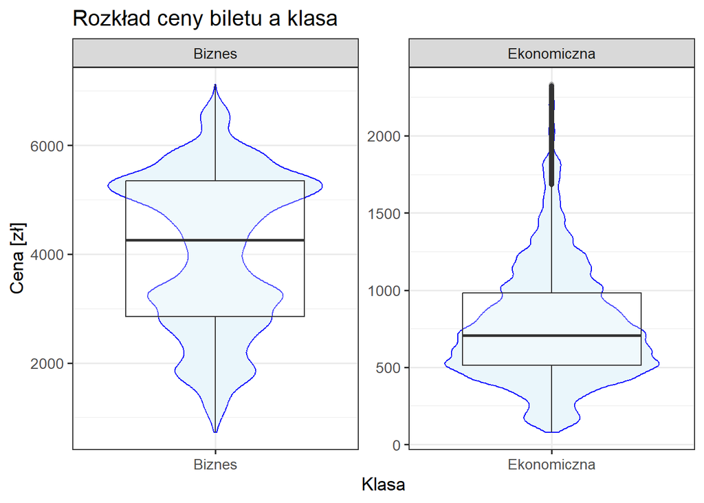

```r
dane %>%
  ggplot(aes(y = `Price [PLN]`, x = Ticket_class)) +
  geom_violin(fill = "#eaf6fb", color = "blue") +
  geom_boxplot(alpha = 0.3) +
  labs(title = "Rozkład ceny biletu a klasa",
       y = "Cena [zł]",
       x = "Klasa") +
  facet_wrap(~Ticket_class, scales = "free") +
  guides(fill = guide_legend("Klasa")) +
  theme_bw(base_size = 13)
```

Spójrzmy jeszcze na statystyki opisowe.

```r
describeBy(dane$`Price [PLN]`, group = dane$Ticket_class)
```

```
##
##  Descriptive statistics by group
## group: Biznes
##    vars     n    mean      sd median trimmed     mad min  max range  skew
## X1    1 11277 4068.74 1415.41   4257 4121.06 1623.45 726 7120  6394 -0.25
##    kurtosis    se
## X1     -1.1 13.33
## ------------------------------------------------------------
## group: Ekonomiczna
##    vars      n   mean     sd median trimmed    mad min  max range skew kurtosis
## X1    1 133036 773.93 377.57    706  740.01 324.69  79 2333  2254 0.96     1.11
##      se
## X1 1.04
```

Średnio lot klasą biznes jest ponad 5-krotnie droższy od lotu klasą ekonomiczną. Uwagę zwraca też skośność prawostronna rozkładu dla klasy ekonomicznej. Może to wynikać z faktu, że ta taryfa zakłada możliwość dokupienia ewentualnych dodatkowych usług, takich jak pierwszeństwo wejścia na pokład samolotu, większy bagaż czy wybór miejsca. Są one oczywiście opcjonalne, ale podnoszą cenę biletu.

### W jaki sposób cena zależy od łącznego czasu podróży?

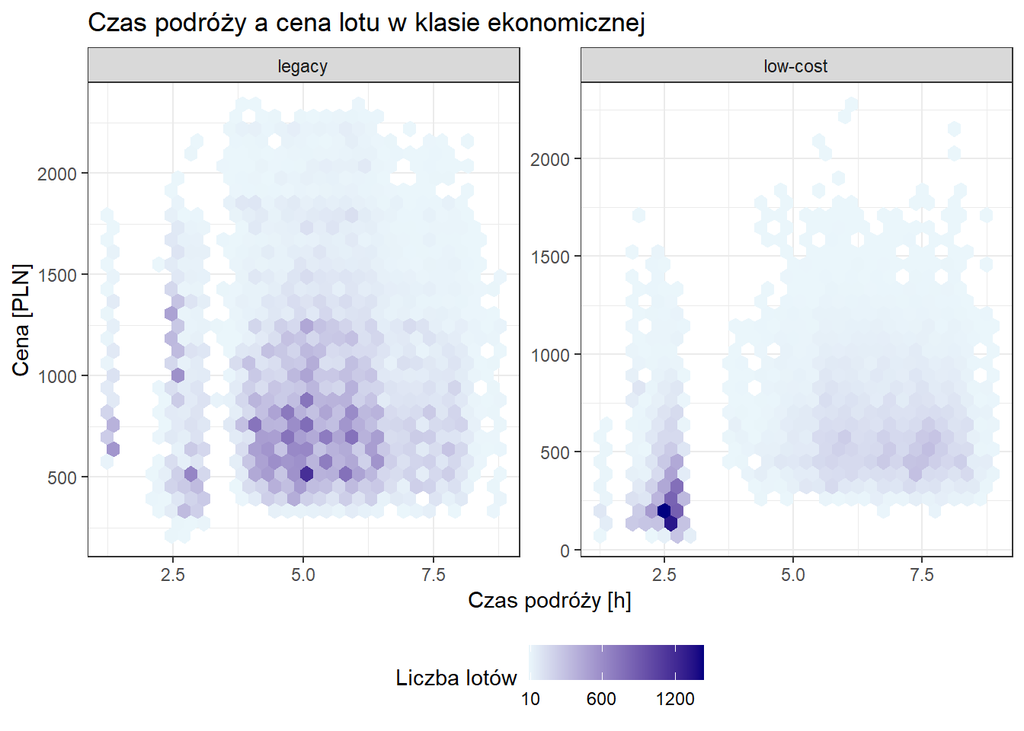

```r
dane %>%
  filter(Ticket_class == "Ekonomiczna") %>%
  # low_cost1 == low_cost2 pozostawia 2-odcinkowe segmenty, takie, że oba odcinki były wykonane albo przez tanią, albo tradycyjną linię lotniczą, low_cost2 == "-" dodaje do tego wszystkie loty bezpośrednie
  filter(low_cost1 == low_cost2 | low_cost2 == "-") %>%
  ggplot(aes(y = `Price [PLN]`, x = Flight_time)) +
  geom_hex() +
  facet_wrap(~low_cost1, scales = "free") +
  labs(title = "Czas podróży a cena lotu w klasie ekonomicznej",
       y = "Cena [PLN]",
       x = "Czas podróży [h]",
       fill = "Liczba lotów") +
    scale_fill_gradient(
    low = "#eaf6fb",
    high = "navyblue",
    breaks = c(10, 600, 1200),
  ) +
  theme_bw() +
  theme(legend.position = "bottom")
```

W przypadku analizowanych segmentów podróż tradycyjną linią lotniczą będzie kosztowała więcej i potrwa, co do zasady, dłużej. Ta druga obserwacja może wynikać z różnych modeli biznesowych: w taniej linii lotniczej dąży się do tego, aby przesiadek było jak najmniej, jest to tzw. siatka połączeń point-to-point. Tradycyjne linie natomiast często posiadają duże huby przesiadkowe, gdzie pasażerowie przesiadają się na dalsze loty. W moich danych te huby to…

```r
huby_przesiadkowe <- dane %>%
  filter(`#Layovers` != 0) %>%
  group_by(layover_airport) %>%
  count() %>%
  arrange(desc(n))

head(huby_przesiadkowe) %>% kable()
```

| layover_airport | n |
| --- | --- |
| AMS | 27840 |
| FRA | 24069 |
| MUC | 20007 |
| WAW | 9037 |
| KRK | 3550 |
| CDG | 3091 |

Głównymi portami przesiadkowymi są zatem:

- Amsterdam (KLM);
- Frankfurt (Lufthansa);
- Monachium (Lufthansa);
- Warszawa (PLL LOT).

Istotnie mniej, ale wciąż dosyć dużo, jest lotów (z Warszawy) z przesiadką w Krakowie oraz lotów z przesiadką w Paryżu (Air France). W nawiasach są nazwy linii lotniczych, dla których dane lotnisko stanowi hub.

### Czy loty bezpośrednie są tańsze czy droższe od tych z przesiadką?

Spójrzmy najpierw, ile lotów jest bezpośrednich, a ile z przesiadką.

```r
dane %>%
  group_by(`#Layovers`) %>%
  count() %>%
  kable()
```

| #Layovers | n |
| --- | --- |
| 0 | 24228 |
| 1 | 120085 |

Lotów z przesiadką jest prawie 5-krotnie więcej niż bezpośrednich.

Spójrzmy na rozkład ceny z podziałem na liczbę przesiadek. Na osi y pokazuję logarytm naturalny z ceny z uwagi na duży zakres jej wartości. Podobnie postąpię również przy wielu innych wykresach. Krzyżykiem zaznaczam przeciętną cenę.

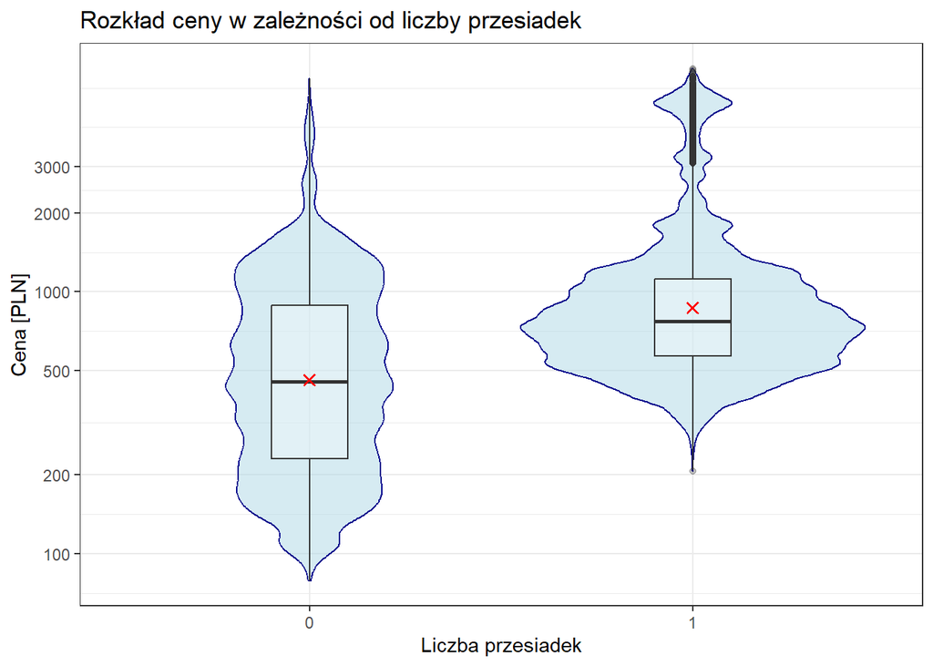

```r
dane %>%
  group_by(`#Layovers`) %>%
  ggplot(aes(y = log(`Price [PLN]`), x = as.factor(`#Layovers`))) +
  geom_violin(fill = "lightblue", color = "darkblue", alpha = 0.5) +
  geom_boxplot(alpha = 0.3, width = 0.2) +
  stat_summary(
    fun = mean,
    geom = "point",
    shape = 4, # kształt krzyżyka
    size = 2,
    color = "red",
    stroke = 1
  ) +
  labs(
    title = "Rozkład ceny w zależności od liczby przesiadek",
    x = "Liczba przesiadek",
    y = "Cena [PLN]"
  ) +
    scale_y_continuous(
    breaks = log(c(50, 100, 200, 500, 1000, 2000, 3000)),
    labels = c(50, 100, 200, 500, 1000, 2000, 3000)
  ) +
  theme_bw()
```

```r
describeBy(dane$`Price [PLN]`, group = dane$`#Layovers`)
```

```
##
##  Descriptive statistics by group
## group: 0
##    vars     n   mean     sd median trimmed    mad min  max range skew kurtosis
## X1    1 24228 642.83 598.51    455  548.15 391.41  79 6511  6432 3.04    15.65
##      se
## X1 3.85
## ------------------------------------------------------------
## group: 1
##    vars      n    mean      sd median trimmed    mad min  max range skew
## X1    1 120085 1109.79 1084.88    772  848.09 358.79 206 7120  6914 3.04
##    kurtosis   se
## X1     9.12 3.13
```

Loty bezpośrednie są prawie dwukrotnie tańsze od tych z jedną przesiadką. Ceny lotów bezpośrednich są rozproszone wokół mediany bardziej, niż ceny lotów z przesiadką.

### Którą linią polecimy najtaniej, a którą najdrożej?

Spójrzmy na rozkład ceny w zależności od linii lotniczej. Pod uwagę biorę tylko segmenty w całości wykonane przez daną linię lotniczą, tzn. wszystkie loty bezpośrednie oraz te z przesiadką, dla których pierwszy i drugi lot wykonała ta sama linia. Uwzględniam też jedynie oferty z klasą ekonomiczną.

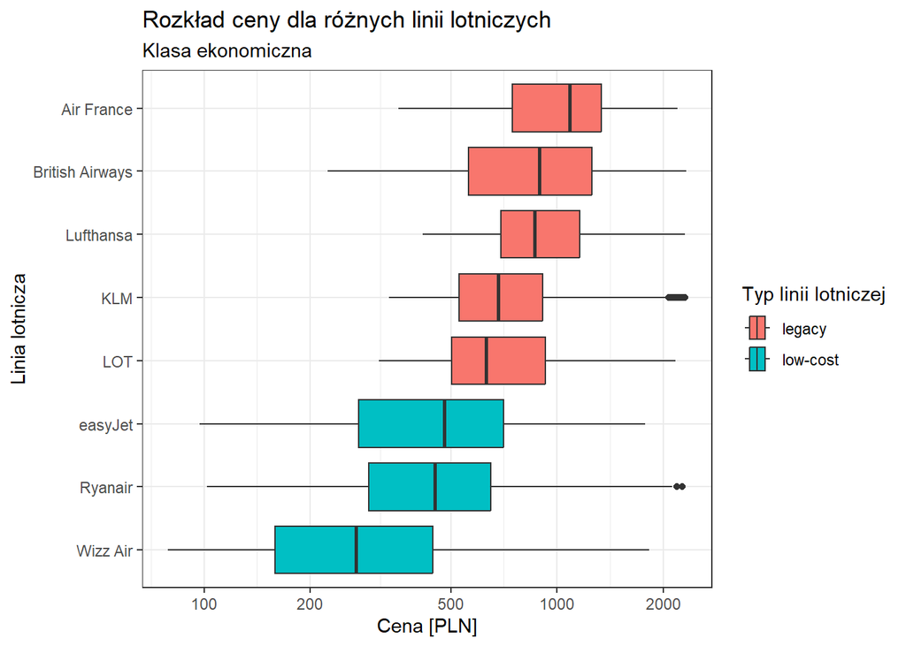

```r
dane %>%
  filter(((Airline1 == Airline2) | Airline2 == "-") & Ticket_class == "Ekonomiczna") %>%
  mutate(Airline1 = fct_reorder(Airline1, `Price [PLN]`, .fun = median, .desc = FALSE)) %>%
  ggplot(aes(x = log(`Price [PLN]`), y = Airline1, fill = low_cost1)) +
  geom_boxplot() +
  labs(
    title = "Rozkład ceny dla różnych linii lotniczych",
    subtitle = "Klasa ekonomiczna",
    x = "Cena [PLN]",
    y = "Linia lotnicza"
  ) +
  guides(fill = guide_legend("Typ linii lotniczej")) +
  scale_x_continuous(
    breaks = log(c(50, 100, 200, 500, 1000, 2000)),
    labels = c(50, 100, 200, 500, 1000, 2000)
  ) +
  theme_bw()
```

Widać, że tradycyjne linie lotnicze mają droższe bilety od tanich przewoźników. Pudełka dla “low-costów” są dłuższe, co wiąże się prawdopodobnie z możliwością dokupienia dodatkowych usług i co za tym idzie większym zróżnicowaniem cen.

Ciekawe byłoby sprawdzenie, czy cena wykazuje większą zmienność dla tanich, czy tradycyjnych linii lotniczych. Pod uwagę biorę oczywiście tylko klasę ekonomiczną.

```r
dane %>%
  filter(Ticket_class == "Ekonomiczna") %>%
  filter(Airline1 == Airline2 | Airline2 == "-") %>%
  group_by(Airline1) %>%
  summarize(wz = round(sd(`Price [PLN]`)/mean(`Price [PLN]`), 2)) %>%
  arrange(desc(wz)) %>%
  rename(`linia lotnicza` = Airline1,
         `współczynnik zmienności` = wz) %>%
  kable()
```

| linia lotnicza | współczynnik zmienności |
| --- | --- |
| Wizz Air | 0.68 |
| easyJet | 0.56 |
| Ryanair | 0.54 |
| British Airways | 0.47 |
| KLM | 0.43 |
| LOT | 0.43 |
| Lufthansa | 0.38 |
| Air France | 0.37 |

Okazuje się, że ceny biletów w klasie ekonomicznej są dla tanich linii bardziej zmienne. Ten fakt stanowi potwierdzenie wcześniejszego przypuszczenia. Tania linia oferuje liczne dodatkowe, opcjonalne usługi, a tradycyjna ma je częściej “w pakiecie” i przez to oferuje bardziej zbliżone do siebie ceny.

Sprawdźmy też rozkład ceny dla kotów w klasie biznes.

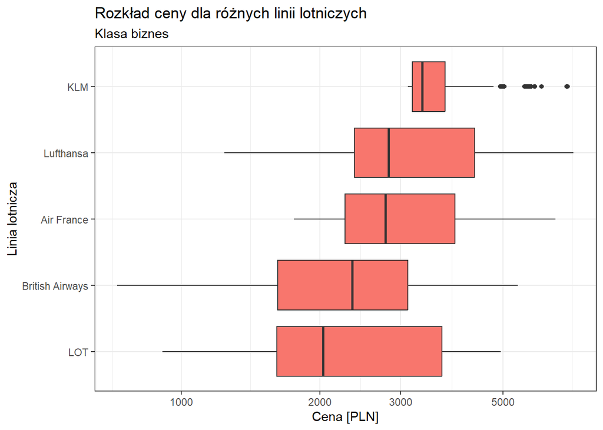

```r
dane %>%
  filter(((Airline1 == Airline2) | Airline2 == "-") & Ticket_class == "Biznes") %>%
  mutate(Airline1 = fct_reorder(Airline1, `Price [PLN]`, .fun = median, .desc = FALSE)) %>%
  ggplot(aes(x = log(`Price [PLN]`), y = Airline1)) +
  geom_boxplot(fill = "#F8766D") +
  labs(
    title = "Rozkład ceny dla różnych linii lotniczych",
    subtitle = "Klasa biznes",
    x = "Cena [PLN]",
    y = "Linia lotnicza"
  ) +
  scale_x_continuous(
    breaks = log(c(500, 1000, 2000, 3000, 5000)),
    labels = c(500, 1000, 2000, 3000, 5000)
  ) +
  theme_bw()
```

Najwięcej drogich lotów w klasie biznes ma KLM. Najtaniej klasą biznes polecimy LOTem.

### W jaki dzień tygodnia polecimy najtaniej, a w jaki najdrożej?

Popatrzmy na rozkład cen w zależności od dnia tygodnia. Najpierw dla tanich linii lotniczych.

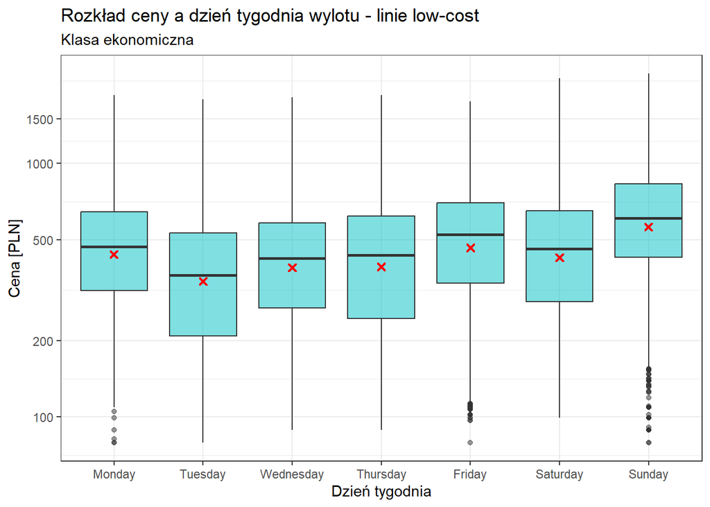

```r
dane %>%
  # pozostaw tylko segmenty z wszystkimi lotami wykonanymi przez linię low-cost
  filter(low_cost1 == "low-cost", low_cost2 %in% c("low-cost", "-")) %>%
  ggplot(aes(x = Flight_weekday, y = log(`Price [PLN]`))) +
  geom_boxplot(fill = "#00BFC4", alpha = 0.5) +
  labs(
    title = "Rozkład ceny a dzień tygodnia wylotu - linie low-cost",
    subtitle = "Klasa ekonomiczna",
    x = "Dzień tygodnia",
    y = "Cena [PLN]",
    fill = "Typ linii lotniczej"
  ) +
  stat_summary(fun = "mean",
               color = "red",
               geom = "point",
               size = 1.5,
               shape =4,
               stroke = 1.25) +
  scale_y_continuous(
    breaks = log(c(100, 200, 500, 1000, 1500)),
    labels = c(100, 200, 500, 1000, 1500)
  ) +
  theme_bw() +
  theme(legend.position = "bottom")
```

Teraz spójrzmy na tradycyjnych przewoźników.

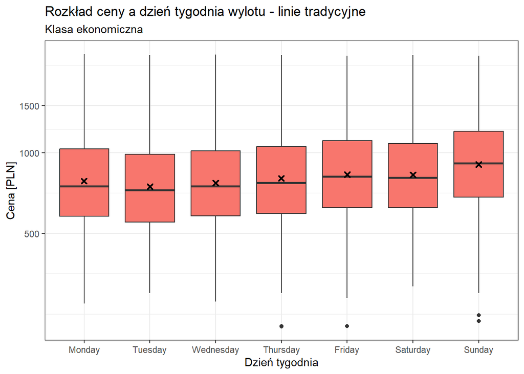

```r
dane %>%
  filter(Ticket_class == "Ekonomiczna") %>%
  filter(low_cost1 == "legacy", low_cost2 %in% c("legacy", "-")) %>%
  ggplot(aes(x = Flight_weekday, y = log(`Price [PLN]`))) +
  geom_boxplot(fill = "#F8766D") +
  labs(
    title = "Rozkład ceny a dzień tygodnia wylotu - linie tradycyjne",
    subtitle = "Klasa ekonomiczna",
    x = "Dzień tygodnia",
    y = "Cena [PLN]",
    fill = "Typ linii lotniczej"
  ) +
  theme_bw() +
  stat_summary(fun = "mean", geom = "point", size = 1.5, shape =4, stroke = 1.25) +
    scale_y_continuous(
    breaks = log(c(500, 1000, 1500)),
    labels = c(500, 1000, 1500)
  ) +
  theme(legend.position = "bottom")
```

Loty w niedzielę są droższe od lotów w pozostałe dni - jest tak i dla tanich, i tradycyjnych przewoźników. Potwierdzimy to w tabeli:

```r
dane %>%
  filter(Ticket_class == "Ekonomiczna") %>%
  filter(low_cost1 == low_cost2 | low_cost2 == "-") %>%  # Segmenty z lotami linii tego samego typu
  group_by(low_cost1, Flight_weekday) %>%
  summarise(srednia_cena = round(mean(`Price [PLN]`), 2)) %>%
  pivot_wider(
    names_from = Flight_weekday,
    values_from = srednia_cena
  ) %>%
  rename("Typ linii lotniczej" = low_cost1) %>%
  kable()
```

| Typ linii lotniczej | Monday | Tuesday | Wednesday | Thursday | Friday | Saturday | Sunday |
| --- | --- | --- | --- | --- | --- | --- | --- |
| legacy | 856.05 | 808.35 | 833.63 | 872.27 | 899.69 | 891.92 | 972.74 |
| low-cost | 505.17 | 412.53 | 456.34 | 468.99 | 538.76 | 498.80 | 637.56 |

Z tabelki wynika, że z reguły loty w piątek i niedzielę okazują się droższe od lotów w pozostałe dni. To można oczywiście łatwo wyjaśnić większym popytem w te dni (trzydniowy lub dwudniowy “city-break”). Najtańsze dla obu typów linii lotniczych są loty we wtorki i środy, kiedy mniej osób lata.

Popatrzmy jeszcze na średnie ceny lotów w klasie ekonomicznej dla poszczególnych linii z podziałem na dni tygodnia.

```r
ceny_dni_tyg_ekon <- dane %>%
  # pozostaw tylko segmenty z wszystkimi lotami tej samej linii
  filter(Ticket_class == "Ekonomiczna", (Airline1 == Airline2 | Airline2 == "-")) %>%
  group_by(Airline1, Flight_weekday) %>%
  summarise(srednia_cena = round(mean(`Price [PLN]`), 2), .groups = "drop") %>%
  pivot_wider(
    names_from = Flight_weekday,
    values_from = srednia_cena
  ) %>%
  rename(
    `linia lotnicza` = Airline1,
  )

ceny_dni_tyg_ekon %>% kable()
```

| linia lotnicza | Monday | Tuesday | Wednesday | Thursday | Friday | Saturday | Sunday |
| --- | --- | --- | --- | --- | --- | --- | --- |
| Air France | 1033.15 | 917.17 | 975.09 | 1074.56 | 1237.68 | 1040.15 | 1180.29 |
| British Airways | 919.25 | 937.46 | 921.26 | 997.95 | 867.15 | 952.57 | 1089.80 |
| KLM | 737.89 | 716.81 | 738.59 | 763.74 | 810.39 | 745.31 | 864.15 |
| LOT | 719.69 | 708.06 | 710.18 | 727.75 | 740.84 | 729.29 | 824.70 |
| Lufthansa | 958.69 | 880.32 | 905.77 | 967.25 | 987.42 | 983.19 | 1059.40 |
| Ryanair | 485.11 | 415.91 | 466.57 | 462.56 | 494.79 | 454.27 | 646.40 |
| Wizz Air | 336.47 | 288.13 | 323.65 | 313.64 | 353.67 | 303.62 | 442.73 |
| easyJet | 568.45 | 349.42 | 520.60 | 365.41 | 559.42 | 468.21 | 678.18 |

Dla wszystkich linii oprócz British Airways wtorek jest dniem, gdy w klasie ekonomicznej polecimy najtaniej. Sprawdźmy, jak duży jest względny wzrost ceny dla każdej linii pomiędzy dniem najtańszym a najdroższym.

```r
min_max_linie_ekon <-ceny_dni_tyg_ekon %>%
  rowwise() %>% # wykonuj operacje na wierszach
  mutate(
    cena_min = min(c_across(where(is.numeric))), # minimum z kolumn numerycznych
    cena_max = max(c_across(where(is.numeric))), # maksimum z kolumn numerycznych
    `wzrost_ceny [%]` = round((cena_max - cena_min) / cena_min * 100, 2) # obliczenie wzrostu ceny
  ) %>%
  arrange(desc(`wzrost_ceny [%]`)) %>% # sortowanie malejąco po wzroście ceny
  select(c(`linia lotnicza`, cena_min, cena_max, `wzrost_ceny [%]`))

min_max_linie_ekon %>% kable()
```

| linia lotnicza | cena_min | cena_max | wzrost_ceny [%] |
| --- | --- | --- | --- |
| easyJet | 349.42 | 678.18 | 94.09 |
| Ryanair | 415.91 | 646.40 | 55.42 |
| Wizz Air | 288.13 | 442.73 | 53.66 |
| Air France | 917.17 | 1237.68 | 34.95 |
| British Airways | 867.15 | 1089.80 | 25.68 |
| KLM | 716.81 | 864.15 | 20.55 |
| Lufthansa | 880.32 | 1059.40 | 20.34 |
| LOT | 708.06 | 824.70 | 16.47 |

Ciekawym wnioskiem jest fakt, że dla tanich linii procentowy wzrost ceny pomiędzy dniem tygodnia najtańszym a najdroższym jest wyraźnie większy, niż dla linii tradycyjnych. Być może jest to związane z tym, że na weekendowy city-break podróżni polecą raczej Ryanairem, a nie Lufthansą. Średnia cena najbardziej zależy od dnia tygodnia dla linii easyJet (prawie 2-krotny wzrost pomiędzy ceną z wtorku a niedzieli), a najmniej dla LOTu.

Skoro zauważamy takie różnice w cenach lotów w poszczególne dni w klasie ekonomicznej, to przyjrzyjmy się też klasie biznes.

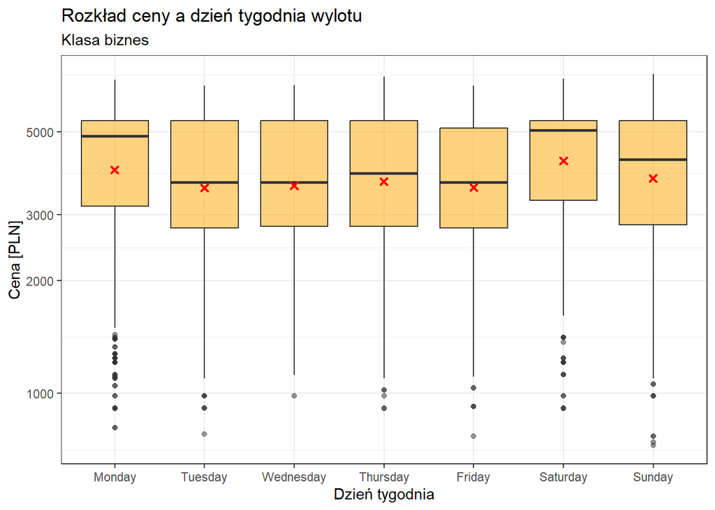

```r
dni_tyg <- c("Monday", "Tuesday", "Wednesday", "Thursday",
             "Friday", "Saturday", "Sunday")

dane <- dane %>%
  mutate(Flight_weekday = factor(Flight_weekday,
                                 levels = dni_tyg))

dane %>%
  filter(Ticket_class == "Biznes") %>%
  ggplot(aes(x = Flight_weekday, y = log(`Price [PLN]`))) +
  geom_boxplot(fill = "orange", alpha = 0.5) +
  labs(
    title = "Rozkład ceny a dzień tygodnia wylotu",
    subtitle = "Klasa biznes",
    x = "Dzień tygodnia",
    y = "Cena [PLN]"
  ) +
  scale_y_continuous(
    breaks = log(c(500, 1000, 2000, 3000, 5000)),
    labels = c(500, 1000, 2000, 3000, 5000)
  ) +
  stat_summary(fun = "mean", color = "red", geom = "point", size = 1.5, shape =4, stroke = 1.25) +
  theme_bw()
```

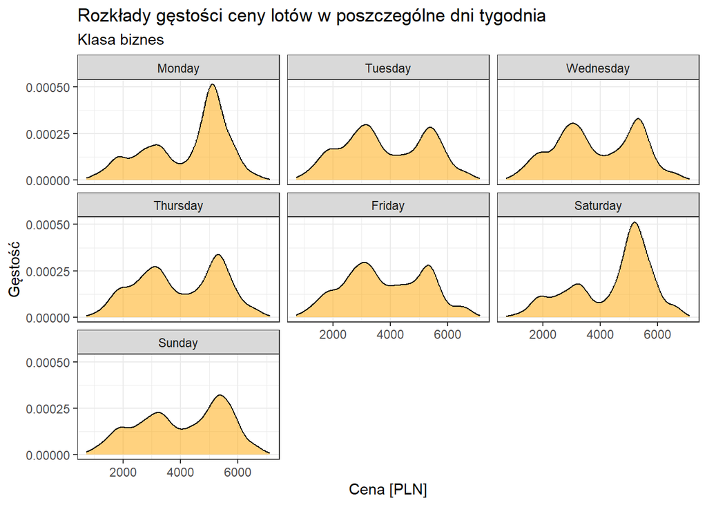

```r
dane %>%
  filter(Ticket_class == "Biznes") %>%
  group_by(Flight_weekday) %>%
  ggplot(aes(x = `Price [PLN]`)) +
  facet_wrap(~Flight_weekday, ncol = 3)+
  geom_density(alpha = 0.5,  fill = "orange") +
  theme_bw() +
  labs(title = "Rozkłady gęstości ceny lotów w poszczególne dni tygodnia",
       subtitle = "Klasa biznes",
       x = "Cena [PLN]",
       y = "Gęstość") +
  scale_y_continuous(breaks = seq(0, 0.0005, 0.00025))
```

Rozkłady dla poniedziałku i soboty wykazują wyraźną skośność lewostronną. W tych dniach jest więcej lotów drogich, o cenach oscylujących wokół 5 tys. zł, niż w pozostałych dniach. Odpowiedź na pytanie, dlaczego tak jest, wymaga dodatkowej analizy.

Sprawdźmy jeszcze procentowy wzrost ceny pomiędzy średnią ceną z “najtańszego” i “najdroższego” dnia tygodnia dla każdej z linii i klasy biznes.

Najpierw tabelka ze średnimi cenami z dni tygodnia:

```r
ceny_dni_tyg_biz <- dane %>%
  # pozostaw tylko segmenty z wszystkimi lotami tej samej linii
  filter(Ticket_class == "Biznes", (Airline1 == Airline2 | Airline2 == "-")) %>%
  group_by(Airline1, Flight_weekday) %>%
  summarise(srednia_cena = round(mean(`Price [PLN]`), 2), .groups = "drop") %>%
  pivot_wider(
    names_from = Flight_weekday,
    values_from = srednia_cena
  ) %>%
  rename(
    `linia lotnicza` = Airline1,
    poniedziałek = Monday,
    wtorek = Tuesday,
    środa = Wednesday,
    czwartek = Thursday,
    piątek = Friday,
    sobota = Saturday,
    niedziela = Sunday
  )

ceny_dni_tyg_biz %>% kable()
```

| linia lotnicza | poniedziałek | wtorek | środa | czwartek | piątek | sobota | niedziela |
| --- | --- | --- | --- | --- | --- | --- | --- |
| Air France | 3116.42 | 2911.78 | 2975.98 | 3053.49 | 3524.14 | 3382.09 | 3441.15 |
| British Airways | 2300.32 | 2139.82 | 2281.47 | 2688.66 | 2449.97 | 2539.78 | 2468.70 |
| KLM | 3677.80 | 3551.56 | 3583.54 | 3523.65 | 3497.02 | 3594.98 | 3657.91 |
| LOT | 2497.71 | 2401.01 | 2505.23 | 2409.84 | 2518.44 | 2552.83 | 2513.74 |
| Lufthansa | 3392.24 | 3403.09 | 3351.67 | 3341.09 | 3493.39 | 3715.34 | 3518.22 |

Teraz liczymy procentowy wzrost ceny.

```r
min_max_linie_biz <-ceny_dni_tyg_biz %>%
  rowwise() %>% # wykonuj operacje na wierszach
  mutate(
    cena_min = min(c_across(where(is.numeric))), # minimum z kolumn numerycznych
    cena_max = max(c_across(where(is.numeric))), # maksimum z kolumn numerycznych
    `wzrost_ceny [%]` = round((cena_max - cena_min) / cena_min * 100, 2) # obliczenie wzrostu ceny
  ) %>%
  arrange(desc(`wzrost_ceny [%]`)) %>% # sortowanie malejąco po wzroście ceny
  select(c(`linia lotnicza`, cena_min, cena_max, `wzrost_ceny [%]`))

min_max_linie_biz %>% kable()
```

| linia lotnicza | cena_min | cena_max | wzrost_ceny [%] |
| --- | --- | --- | --- |
| British Airways | 2139.82 | 2688.66 | 25.65 |
| Air France | 2911.78 | 3524.14 | 21.03 |
| Lufthansa | 3341.09 | 3715.34 | 11.20 |
| LOT | 2401.01 | 2552.83 | 6.32 |
| KLM | 3497.02 | 3677.80 | 5.17 |

Wybierając klasę biznes, z największym wzrostem średniej ceny pomiędzy “najtańszym” a “najdroższym” dniem tygodnia musimy się liczyć, kiedy lecimy British Airways. Dla LOTu i KLM jest on natomiast względnie niewielki.

Sprawdźmy, jak zmienia się cena lotu w zależności od liczby dni pozostałych do odlotu.

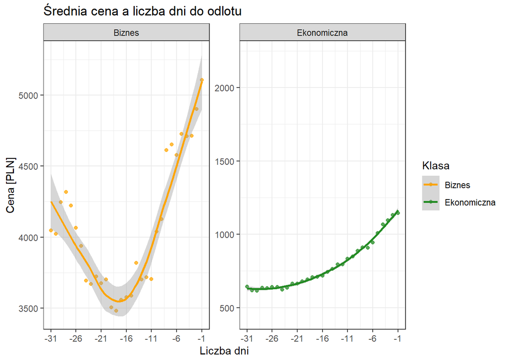

```r
dane$ujemne = -1*dane$Days_to_departure

cena_dni_do_odlotu <- dane %>%
  group_by(ujemne, Ticket_class) %>%
  summarize(srednia_cena = mean(`Price [PLN]`))

  ggplot(cena_dni_do_odlotu, aes(x = ujemne, y = srednia_cena, color = Ticket_class)) +
  geom_point(alpha = 0.75) +
  geom_smooth(formula = y~ x, method = "loess") +
  scale_x_continuous(breaks = seq(-31, -1, 5), limits = c(-31, -1)) +
  facet_wrap(~Ticket_class, scales = "free_y") +
  scale_color_manual(values = c("Ekonomiczna" = "#228B22", "Biznes" = "orange")) +
  labs(title = "Średnia cena a liczba dni do odlotu",
       x = "Liczba dni",
       y = "Cena [PLN]",
       color = "Klasa") +
  theme_bw()
```

Jak widać, zależności między ceną a liczbą dni do odlotu są różne w zależności od klasy. W analizowanym okresie 31 dni do odlotu cena lotu w klasie ekonomicznej jest tym większa, im mniej dni zostało do odlotu. Zależność jest w przybliżeniu liniowa,co potwierdza współczynnik korelacji Pearsona:

```r
cat("Współczynnik korelacji Pearsona pomiędzy liczbą dni do odlotu a ceną biletu w klasie ekonomicznej wynosi:",
    round(cor(
      cena_dni_do_odlotu$srednia_cena[cena_dni_do_odlotu$Ticket_class == "Ekonomiczna"],
      cena_dni_do_odlotu$ujemne[cena_dni_do_odlotu$Ticket_class == "Ekonomiczna"]), 2))
```

```
## Współczynnik korelacji Pearsona pomiędzy liczbą dni do odlotu a ceną biletu w klasie ekonomicznej wynosi: 0.77
```

Jest to zatem silna dodatnia zależność.

W klasie biznes natomiast widoczny jest bardzo mocny spadek do mniej więcej 17 dni przed odlotem, po czym cena zaczyna gwałtownie wzrastać. Zbadanie tej dynamiki cen w dłuższym okresie mogłoby z pewnością być bardzo ciekawym elementem kolejnych badań.

Ciekawe byłoby też sprawdzenie, czy w obrębie klasy ekonomicznej ta tedencja wzrostowa ma różny charakter w zależności od typu linii lotniczej: “low-cost” lub tradycyjna. Oczywiście zastosuję filtr gwarantujący, że jeśli segment jest z przesiadką, to oba loty muszą być wykonane przez linię tego samego typu.

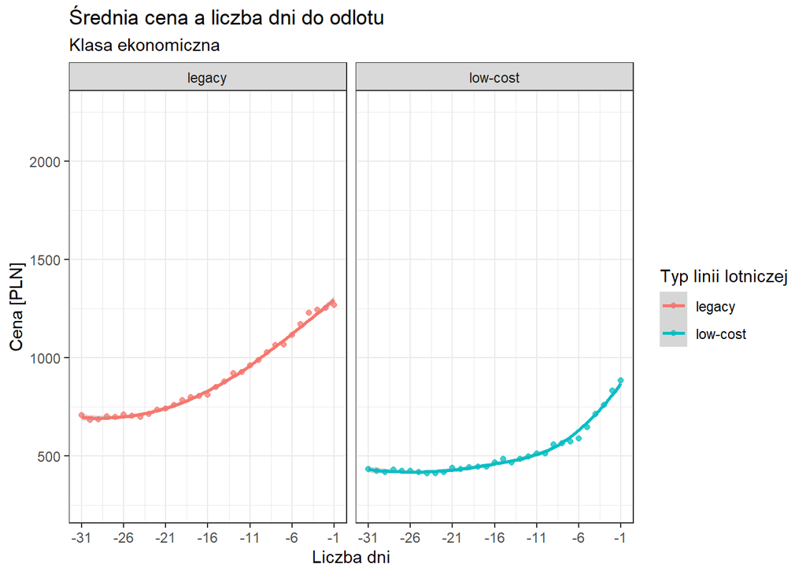

```r
dane %>%
  filter(Ticket_class == "Ekonomiczna" & (low_cost1 == low_cost2 | low_cost2 == "-")) %>%
  group_by(ujemne, low_cost1) %>%
  summarize(srednia_cena = mean(`Price [PLN]`)) %>%
  ggplot(aes(x = ujemne, y = srednia_cena, color = low_cost1)) +
  geom_point(alpha = 0.75) +
  geom_smooth(formula = y~ x, method = "loess") +
  facet_wrap(~low_cost1, ncol = 2) +
  scale_x_continuous(breaks = seq(-31, -1, 5), limits = c(-31, -1)) +
  labs(title = "Średnia cena a liczba dni do odlotu",
       subtitle = "Klasa ekonomiczna",
       x = "Liczba dni",
       y = "Cena [PLN]",
       color = "Typ linii lotniczej") +
  theme_bw()
```

Wykresy nie różnią się znacznie, jednak widać, że dla tanich linii lotniczych cena zaczyna wzrastać bardziej po 11 dniu przed odlotem, a dla tradycyjnych linii wzrost ma charakter nieco bardziej liniowy i rozpoczyna się trochę wcześniej, w okolicach 18 dni przed wylotem.

### Czy to, w jakim dniu tygodnia kupię bilet, wpływa na jego cenę?

Sprawdźmy to dla klasy ekonomicznej.

```r
dane %>%
  filter(Ticket_class == "Ekonomiczna", low_cost1 == low_cost2 | low_cost2 == "-") %>%
  group_by(Extraction_Weekday, low_cost1) %>%
  summarize(srednia = round(mean(`Price [PLN]`, na.rm = TRUE, .groups = "drop"),2)) %>%
  pivot_wider(names_from = low_cost1, values_from = srednia) %>%
  rename("Dzień tygodnia zakupu biletu" = Extraction_Weekday,
         "Linia tradycyjna" = legacy) %>%
  arrange(`Dzień tygodnia zakupu biletu`) %>%
  kable()
```

| Dzień tygodnia zakupu biletu | Linia tradycyjna | low-cost |
| --- | --- | --- |
| Monday | 891.11 | 496.18 |
| Tuesday | 835.03 | 498.21 |
| Wednesday | 873.01 | 514.98 |
| Thursday | 881.26 | 518.90 |
| Friday | 853.04 | 516.56 |
| Saturday | 891.06 | 519.53 |
| Sunday | 871.47 | 521.21 |

Różnice w cenach są minimalne, nieznaczące. Dla klasy ekonomicznej dzień tygodnia zakupu biletu nie wpływa istotnie na jego cenę. A jak to wygląda dla klasy biznes?

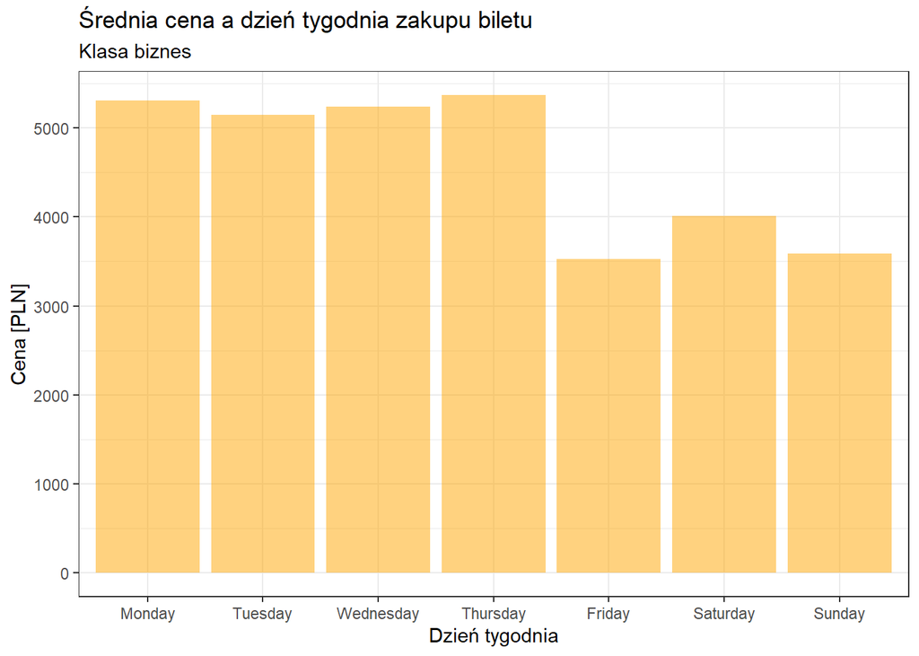

```r
dane %>%
  filter(Ticket_class == "Biznes") %>%
  group_by(Extraction_Weekday) %>%
  summarize(srednia = mean(`Price [PLN]`, na.rm = TRUE)) %>%
  ggplot(aes(x = Extraction_Weekday, y = srednia)) +
  geom_col(fill = "orange", alpha = 0.5) +
  labs(title = "Średnia cena a dzień tygodnia zakupu biletu",
       subtitle = "Klasa biznes",
       x = "Dzień tygodnia",
       y = "Cena [PLN]") +
  scale_y_continuous(breaks = seq(0, 5000, 1000))+
  theme_bw()
```

Okazuje się, że kiedy podróżujemy w klasie biznes, nie bez znaczenia dla ceny biletu jest dzień jego zakupu. Aby przyoszczędzić, powinniśmy bilet kupić w piątek, sobotę lub niedzielę. Należy tu jednak zaznaczyć, że w zbiorze danych znajduje się stosunkowo niewiele lotów w klasie biznes i tylko kilka linii, które takie loty oferują. W związku z tym nie mam pewności, czy tak wyraźny spadek stanowi ogólną prawidłowość, czy anomalię zachodzącą tylko dla moich danych. Rozwianie tych wątpliwości wymaga dodatkowych badań.

### Czy na cenę wpływa godzina odlotu?

Godziny z największą liczbą odlotów dobrze pokaże wykres gęstości.

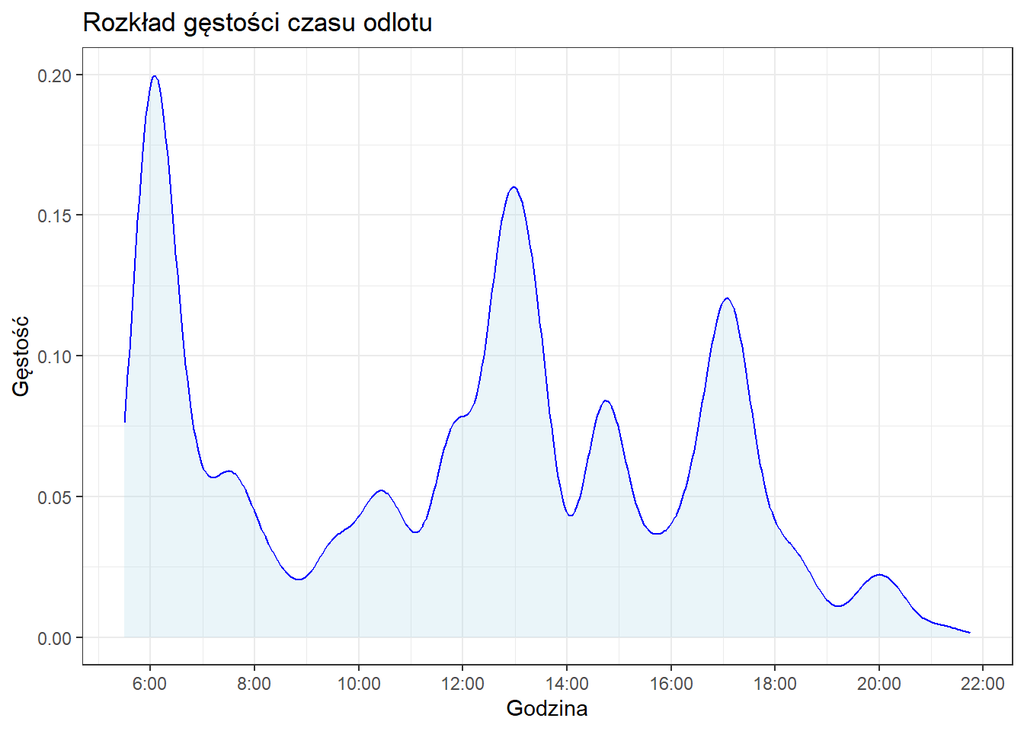

```r
dane %>%
  ggplot(aes(x = Departure_time)) +
  geom_density(alpha = 0.25, color = "blue", fill = "lightblue") +
  labs(
    title = "Rozkład gęstości czasu odlotu",
    x = "Godzina",
    y = "Gęstość"
  ) +
  scale_x_continuous(breaks = seq(6, 22, 2),
                     labels = paste0(seq(6, 22, 2), ":00")) +
  theme_bw()
```

Wyraźnie widzimy, że najwięcej wylotów było około 6 rano. Dużo samolotów odlatywało też o 13.00 i 17.00.

Sprawdźmy, czy wylot o godzinie, o której startuje wiele samolotów, jest droższy. W tym celu użyjemy funkcji `rollapply`. Policzymy średnią ruchomą z ceny uszeregowanych wg godziny odlotu lotów, stosując okno o szerokości 1000 lotów.

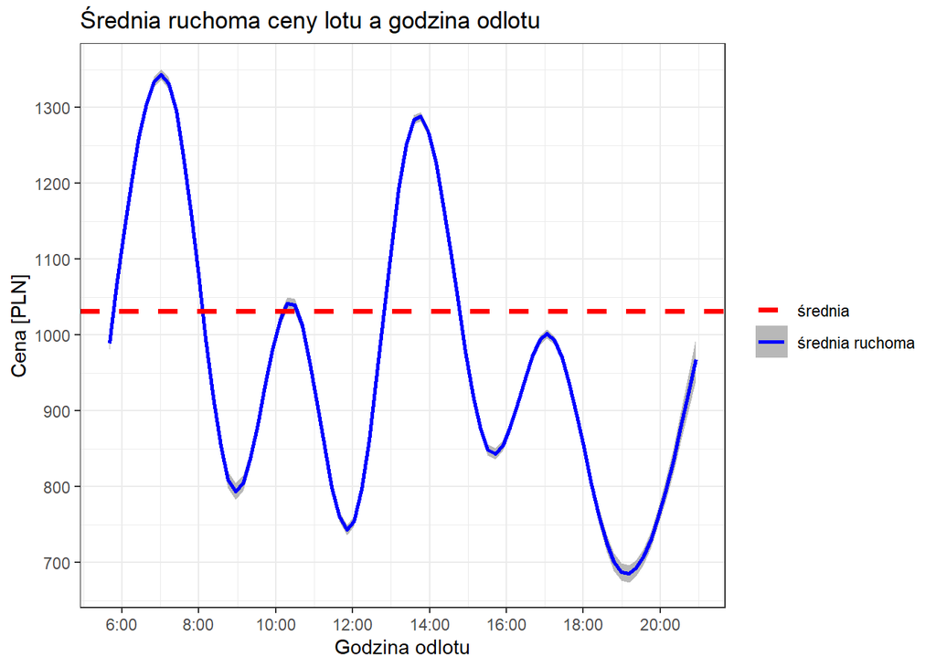

```r
library(zoo)

dane %>%
  # trzeba posortować dane wg godz. odlotu
  arrange(Departure_time) %>%
  # tworzymy średnią ruchomą
  mutate(sr_ruchoma = rollapply(
    data = `Price [PLN]`,
    width = 1000, #okno, z którego liczymy średnią ma szerokość 1000 lotów.
    # ustawienie na.rm = TRUE w funkcji mean powoduje, że
    # dopuszczamy liczenie średniej dla okna o szer. < 1000
    FUN = function(x) mean(x, na.rm=TRUE),
    align = "center",
    fill = NA
  )) %>%
  ggplot(aes(x = Departure_time)) +
  geom_smooth(aes(y = sr_ruchoma, color = "średnia ruchoma"), alpha = 0.7) +
  labs(
    title = "Średnia ruchoma ceny lotu a godzina odlotu",
    x = "Godzina odlotu",
    y = "Cena [PLN]",
  ) +
  geom_hline(aes(yintercept = mean(dane$`Price [PLN]`),
                 color = "średnia"),
             linetype = "dashed",
             size = 1.25) +
  scale_x_continuous(breaks = seq(6, 22, 2),
                     labels = paste0(seq(6, 22, 2), ":00")) +
  scale_color_manual(values = c("średnia" = "red",
                                "średnia ruchoma" = "blue")) +
  guides(color = guide_legend(title = NULL)) +
  scale_y_continuous(breaks = seq(700, 1400, 100)) +
  theme_bw()
```

Czerwoną przerywaną linią oznaczono średnią cenę lotu. Widzimy, że loty przeciętnie najdroższe wylatywały około godziny 7 rano i w okolicy godziny 14.00. Te największe piki pokrywają się z godzinami szczytu widocznymi na poprzednim wykresie. Odlatując o tych porach przeciętnie zapłacimy więcej za nasz lot. Najtaniej wyjdzie nas wylot około godziny 19.00. Średnio zapłacimy wtedy prawie dwukrotnie mniej, niż przy wylocie o 7.00.

### Czy na cenę wpływa godzina przylotu?

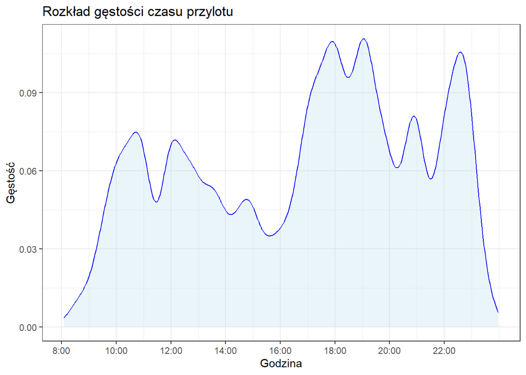

```r
dane %>%
  # przed godziną 8:00 przylatują jedynie pojedyncze samoloty - usuwam je dla czytelności wykresu
  filter(Arrival_time >=8) %>%
  ggplot(aes(x = Arrival_time)) +
  geom_density(alpha = 0.25, color = "blue", fill = "lightblue") +
  labs(
    title = "Rozkład gęstości czasu przylotu",
    x = "Godzina",
    y = "Gęstość"
  ) +
  scale_x_continuous(breaks = seq(6, 22, 2),
                     labels = paste0(seq(6, 22, 2), ":00")) +
  theme_bw()
```

Godziny szczytu jeśli chodzi o przyloty to 17.00-19.00. Dużo przylotów odbywa się też późnym wieczorem, tj. po godzinie 22.00. Wykonujemy procedurę analogiczną do tej przeprowadzonej powyżej. Na wykresie pokażemy średnią ruchomą ceny lotu w zależności od godziny przylotu.

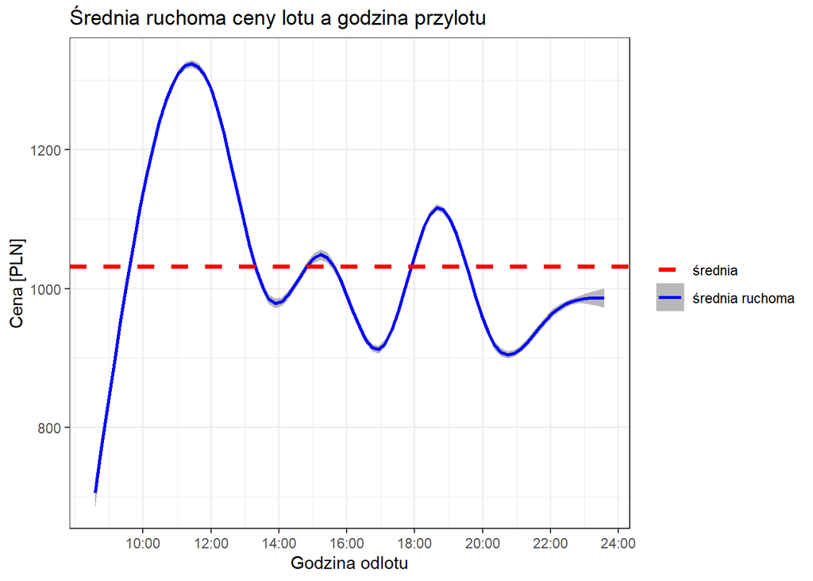

```r
library(zoo)

dane %>%
  filter(Arrival_time > 8) %>% # przed godziną 8:00 przylatują jedynie pojedyncze samoloty - usuwam je dla czytelności wykresu
  # trzeba posortować dane wg godz. przylotu
  arrange(Arrival_time) %>%
  # tworzymy średnią ruchomą
  mutate(sr_ruchoma = rollapply(
    data = `Price [PLN]`,
    width = 1000, #okno, z którego liczymy średnią ma szerokość 1000 lotów.
    FUN = mean,
    align = "center",
    fill = NA
  )) %>%
  ggplot(aes(x = Arrival_time)) +
  geom_smooth(aes(y = sr_ruchoma, color = "średnia ruchoma"), alpha = 0.7) +
  labs(
    title = "Średnia ruchoma ceny lotu a godzina przylotu",
    x = "Godzina odlotu",
    y = "Cena [PLN]",
  ) +
  geom_hline(aes(yintercept = mean(dane$`Price [PLN]`), color = "średnia"), linetype = "dashed", size = 1.25) +
  scale_x_continuous(breaks = seq(10, 24, 2),
                     labels = paste0(seq(10, 24, 2), ":00")) +
  scale_color_manual(values = c("średnia" = "red", "średnia ruchoma" = "blue")) +
  guides(color = guide_legend(title = NULL)) +
  theme_bw()
```

Najdroższe są loty przylatujące późnym rankiem (a więc te, które wyleciały wczesnym rankiem z Polski). Bilety na loty przylatujące wieczorem (18.00-19.00) mają ceny nieco wyższe od przeciętnej, ale to odchylenie nie jest znaczne.

Popatrzmy na średnią cenę lotu w zależności od destynacji.

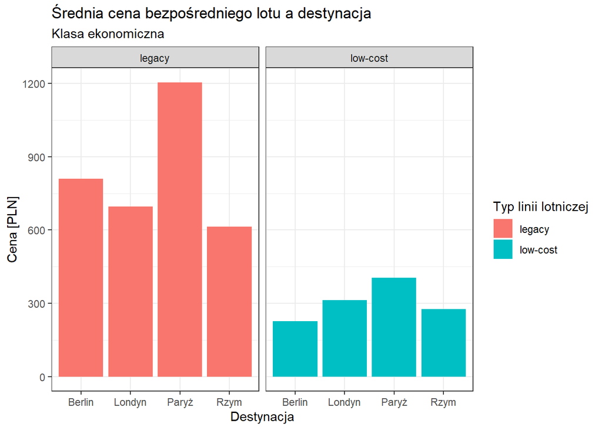

```r
dane %>%
  filter(Ticket_class == "Ekonomiczna", `#Layovers` ==0) %>%
  group_by(arr_city, low_cost1) %>%
  summarise(srednia_cena = mean(`Price [PLN]`)) %>%
  ggplot(aes(x = arr_city, y = srednia_cena, fill = low_cost1)) +
  geom_col() +
  facet_wrap(~low_cost1) +
  labs(title = "Średnia cena bezpośredniego lotu a destynacja",
       subtitle = "Klasa ekonomiczna",
       x = "Destynacja",
       y = "Cena [PLN]",
       fill = "Typ linii lotniczej") +
  scale_y_continuous(breaks = seq(0, 1600, 300)) +
  theme_bw()
```

Najdroższe okazują się loty do Paryża.

Sprawdźmy, czy dla klasy biznes jest podobnie.

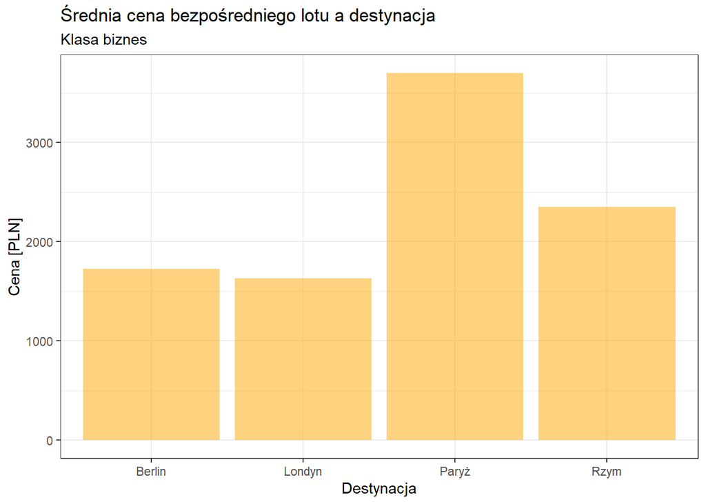

```r
dane %>%
  filter(Ticket_class == "Biznes", `#Layovers` ==0) %>%
  group_by(arr_city) %>%
  summarise(srednia_cena = mean(`Price [PLN]`)) %>%
  ggplot(aes(x = arr_city, y = srednia_cena)) +
  geom_col(fill = "orange", alpha = 0.5) +
  labs(title = "Średnia cena bezpośredniego lotu a destynacja",
       subtitle = "Klasa biznes",
       x = "Destynacja",
       y = "Cena [PLN]") +
  theme_bw()
```

Wśród lotów klasą biznes również najdroższe są loty do Paryża.

### Jak bardzo na cenę lotu wpływa posiadanie bagażu rejestrowanego?

Sprawdzimy to dla poszczególnych linii:

```r
cena_walizka <- dane %>%
  filter(Ticket_class == "Ekonomiczna", Airline1 == Airline2 | Airline2 == "-") %>%
  group_by(Airline1, Checked_bag) %>%
  summarize(srednia = round(mean(`Price [PLN]`),2)) %>%
  pivot_wider(
    names_from = Checked_bag,
    values_from = srednia
  ) %>%
  rename(
    "Linia lotnicza" = Airline1,
    "Bez walizki" = "0",
    "1 walizka" = "1"
  ) %>%
    mutate(`wzrost ceny [%]` = round((`1 walizka` - `Bez walizki`)/`Bez walizki`*100,2)) %>%
  arrange(desc(`wzrost ceny [%]`))

cena_walizka %>% kable()
```

| Linia lotnicza | Bez walizki | 1 walizka | wzrost ceny [%] |
| --- | --- | --- | --- |
| Wizz Air | 331.52 | 638.21 | 92.51 |
| British Airways | 759.66 | 1264.94 | 66.51 |
| Lufthansa | 929.00 | 1304.54 | 40.42 |
| LOT | 732.72 | 939.28 | 28.19 |
| KLM | 762.92 | 925.80 | 21.35 |
| Air France | 1047.68 | 1237.79 | 18.15 |
| Ryanair | 496.30 | 555.74 | 11.98 |
| easyJet | 526.42 | NA | NA |

Podróż z bagażem rejestrowanym jest oczywiście droższa. Jednak wzrost ceny w przypadku linii Ryanair, wynoszący zaledwie około 60 zł, na pewno nie odzwierciedla rzeczywistej dopłaty za bagaż. Powinna być ona znacznie wyższa. Obserwując ceny lotów na stronie momondo, doszedłem do wniosku, że czasem wyświetlana informacja nie jest prawdziwa. Jako walizka może zostać potraktowany np. dodatkowy bagaż podręczny - te błędy wynikają z mnogości taryf oferowanych przez różne linie lotnicze.

### Czy na cenę lotu wpływa czas przesiadki?

Aby odpowiedzieć na to pytanie, policzymy współczynnik korelacji Pearsona - najpierw dla klasy ekonomicznej.

```r
dane %>%
  filter(Ticket_class == "Ekonomiczna", Airline1 == Airline2) %>%
  group_by(Airline1) %>%
  summarise(korelacja = cor(layover_duration, `Price [PLN]`)) %>%
  arrange(korelacja) %>%
  rename("Linia lotnicza" = Airline1) %>%
  kable()
```

| Linia lotnicza | korelacja |
| --- | --- |
| British Airways | -0.2963938 |
| Air France | -0.1655010 |
| Ryanair | -0.0650948 |
| KLM | -0.0525733 |
| Lufthansa | -0.0280682 |
| Wizz Air | -0.0092119 |
| easyJet | -0.0055870 |
| LOT | 0.0548576 |

Widzimy słabą ujemną korelację pomiędzy czasem przesiadki a ceną dla linii British Airways i Air France. Dla pozostałych linii korelacja nie występuje.

Sprawdźmy to samo dla klasy biznes.

```r
dane %>%
  filter(Ticket_class == "Biznes", Airline1 == Airline2) %>%
  group_by(Airline1) %>%
  summarise(korelacja = cor(layover_duration, `Price [PLN]`)) %>%
  arrange(korelacja) %>%
  rename("linia lotnicza" = Airline1) %>%
  kable()
```

| linia lotnicza | korelacja |
| --- | --- |
| LOT | -0.2695669 |
| British Airways | -0.1612828 |
| Lufthansa | -0.0001567 |
| KLM | 0.0031724 |
| Air France | 0.1077450 |

Tu znowu widoczna jest słaba ujemna korelacja dla linii LOT i British Airways, i, o dziwo, słaba dodatnia korelacja dla linii Air France. Trudno o daleko idące wnioski…

### O ile drożej lub taniej wyjdzie mnie lot z Krakowa przez Warszawę, w porównaniu do bezpośredniego lotu z Warszawy i bezpośredniego z Krakowa?

```r
przesiadka_waw <- dane %>%
  filter(layover_airport %in% c("WAW", "WMI") & Ticket_class == "Ekonomiczna") %>%
  group_by(arr_city) %>%
  summarize(srednia_cena = round(mean(`Price [PLN]`), 2)) %>%
  mutate(lot = "Z Krakowa, przesiadka w Warszawie")

bezp_waw <- dane %>%
  filter(`#Layovers` ==0 & dep_city == "Warszawa"  & Ticket_class == "Ekonomiczna") %>%
  group_by(arr_city) %>%
  summarize(srednia_cena =  round(mean(`Price [PLN]`), 2)) %>%
  mutate(lot = "Bezpośredni z Warszawy")

bezp_krk <- dane %>%
  filter(`#Layovers` ==0 & dep_city == "Kraków"  & Ticket_class == "Ekonomiczna") %>%
  group_by(arr_city) %>%
  summarize(srednia_cena =  round(mean(`Price [PLN]`), 2)) %>%
  mutate(lot = "Bezpośredni z Krakowa")

razem <- rbind(przesiadka_waw, bezp_krk, bezp_waw)
razem %>%
  kable()
```

| arr_city | srednia_cena | lot |
| --- | --- | --- |
| Berlin | 712.38 | Z Krakowa, przesiadka w Warszawie |
| Londyn | 621.54 | Z Krakowa, przesiadka w Warszawie |
| Paryż | 668.49 | Z Krakowa, przesiadka w Warszawie |
| Rzym | 729.62 | Z Krakowa, przesiadka w Warszawie |
| Berlin | 227.47 | Bezpośredni z Krakowa |
| Londyn | 327.31 | Bezpośredni z Krakowa |
| Paryż | 413.28 | Bezpośredni z Krakowa |
| Rzym | 320.85 | Bezpośredni z Krakowa |
| Berlin | 809.16 | Bezpośredni z Warszawy |
| Londyn | 553.17 | Bezpośredni z Warszawy |
| Paryż | 1089.39 | Bezpośredni z Warszawy |
| Rzym | 361.33 | Bezpośredni z Warszawy |

Przedstawmy to na wykresie.

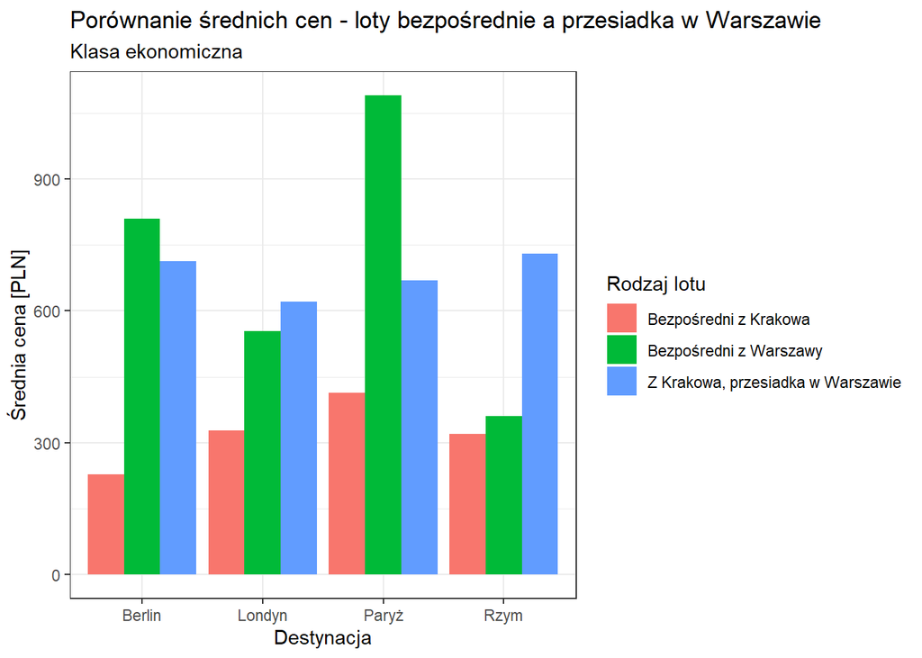

```r
ggplot(razem, aes(x = arr_city, y = srednia_cena, fill = fct_reorder(lot, srednia_cena))) +
  geom_col(position = "dodge") +
  labs(title = "Porównanie średnich cen - loty bezpośrednie a przesiadka w Warszawie",
       subtitle = "Klasa ekonomiczna",
       x = "Destynacja",
       y = "Średnia cena [PLN]",
       fill = "Rodzaj lotu") +
  theme_bw()
```

Najtańsze spośród 3 grup przedstawionych na wykresie są loty bezpośrednie z Krakowa. Być może wynika to z faktu, że krakowskie lotnisko, z uwagi na niższe opłaty związane z lądowaniem i obsługą naziemną samolotu, jest tym preferowanym wśród tanich linii. Sprawdźmy to.

```r
dane %>%
  group_by(Departure_airport_code) %>%
  summarize(
    tanie_linie_loty = sum(low_cost1 == "low-cost"),
    loty_z_lotniska = n()
  ) %>%
  mutate(`odsetek odlotów tanich linii` = round(tanie_linie_loty / loty_z_lotniska, 2)) %>%
  select(Departure_airport_code, `odsetek odlotów tanich linii`) %>%
  rename(lotnisko = Departure_airport_code) %>%
  kable()
```

| lotnisko | odsetek odlotów tanich linii |
| --- | --- |
| KRK | 0.31 |
| WAW | 0.15 |
| WMI | 1.00 |

Hipoteza jest potwierdzona. Odsetek liczby ofert na loty tanich linii z Krakowa jest niemal dwukrotnie większy niż na lotnisku Chopina. Dlatego przeciętnie najniższą cenę będą mieć loty bezpośrednie z Krakowa. Przy okazji, warto zauważyć, że z Modlina (WMI) latają wyłącznie niskokosztowi przewoźnicy (w zestawie danych mamy jednak bardzo niewiele lotów z tego lotniska, dlatego nie wpływa to znacznie na średnią cenę lotu z Warszawy).

### Ceny lotów - czy na przestrzeni jednego miesiąca widać trend wzrostowy lub spadkowy?

Aby odpowiedzieć na to pytanie, najpierw narysuję wykres przedstawiający średnie ceny lotów, liczone tylko z ofert pobranych z momondo na dzień przed odlotem.

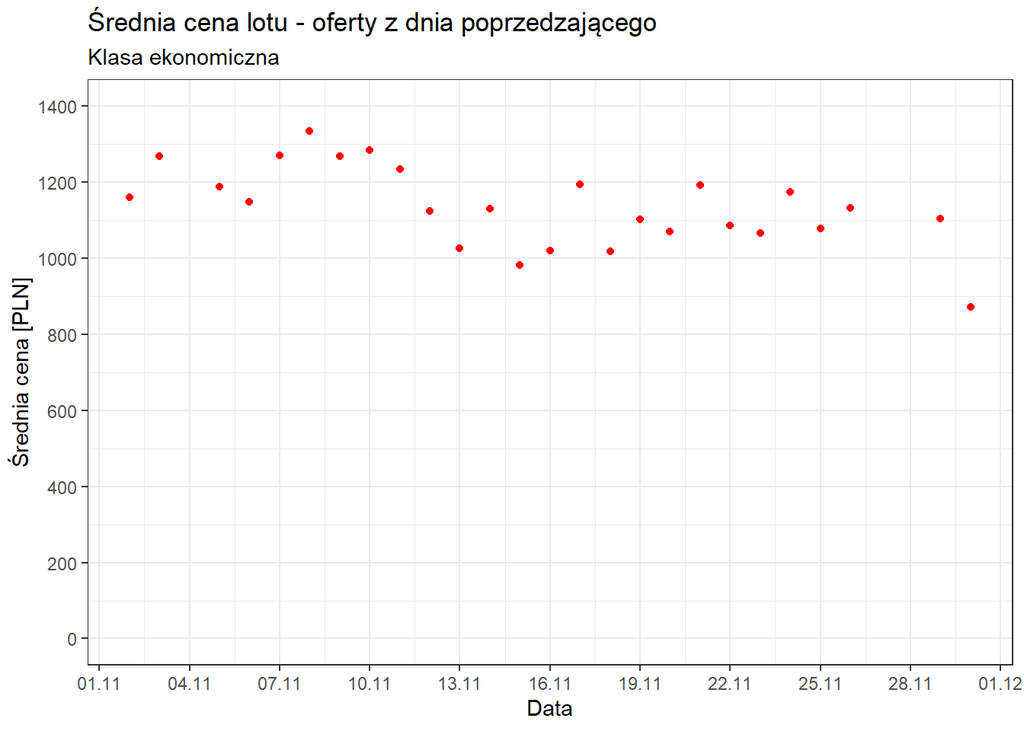

```r
dane %>%
  mutate(Flight_date = as.Date(Flight_date)) %>%
  filter(Ticket_class == "Ekonomiczna" & Days_to_departure ==1) %>%
  group_by(Flight_date) %>%
  summarize(srednia_cena = mean(`Price [PLN]`, na.rm = TRUE)) %>%
  ggplot(aes(x = Flight_date, y = srednia_cena)) +
  geom_point(color = "red") +
  scale_x_date(date_breaks = "3 days", date_labels = "%d.%m") +
  scale_y_continuous(breaks = seq(0, 1400, 200), limits = c(0, 1400)) +
  labs(
    title = "Średnia cena lotu - oferty z dnia poprzedzającego",
    subtitle = "Klasa ekonomiczna",
    x = "Data",
    y = "Średnia cena [PLN]"
  ) +
  theme_bw()
```

Widać, że występują dni, kiedy nie pobrałem wartości cen lotów (ze względu na problemy z działaniem programu lub koniecznością dostosowania jego działania). Trend nie jest tutaj wyraźnie widoczny.

Zrobię ten sam wykres, ale tym razem do liczenia średniej ceny dla danego lotu wezmę wartości jego cen pobierane przez 7 przed tym lotem. Dane zbieram od 1 listopada, więc 8 listopada jest pierwszym dniem, dla którego mogę policzyć średnią z pełnych 7 dni.

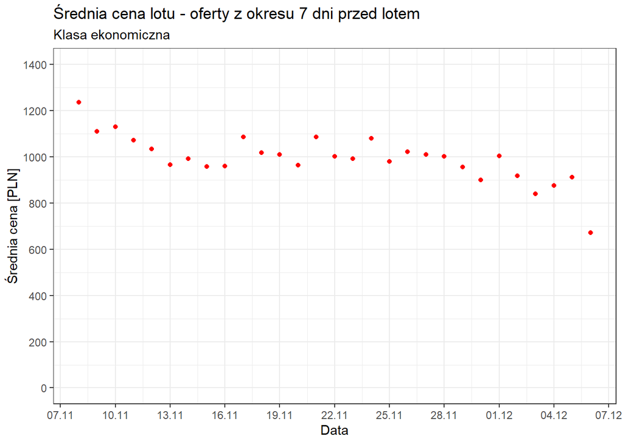

```r
dane %>%
  mutate(Flight_date = as.Date(Flight_date)) %>%
  filter(Flight_date > "2024-11-07") %>%
  filter(Ticket_class == "Ekonomiczna" & Days_to_departure < 8) %>%
  group_by(Flight_date) %>%
  summarize(srednia_cena = mean(`Price [PLN]`, na.rm = TRUE)) %>%
  ggplot(aes(x = Flight_date, y = srednia_cena)) +
  geom_point(color = "red") +
  scale_x_date(date_breaks = "3 days", date_labels = "%d.%m") +
  scale_y_continuous(breaks = seq(0, 1400, 200), limits = c(0, 1400)) +
  labs(
    title = "Średnia cena lotu - oferty z okresu 7 dni przed lotem",
    subtitle = "Klasa ekonomiczna",
    x = "Data",
    y = "Średnia cena [PLN]"
  ) +
  theme_bw()
```

Otrzymany wykres nie jest idealny. Z uwagi na widoczne wcześniej braki cen dla dni: 4.11, 27.11, 28.11, 1.12 (czyli dane niepobrane 3.11, 26.11, 27.11, 30.11) średnia dla niektórych dni została policzona nie z pełnego okresu 7 dni przed wylotem, tylko z mniejszej liczby dni. Niemniej, zaczyna być widoczny lekki trend spadkowy. Aby zobaczyć go lepiej, możemy posłużyć się tygodniową średnią ruchomą. Będziemy więc liczyć średnie tygodniowe ze średnich cen lotów pobranych na 7 dni przed lotem. W obliczeniu średniej ruchomej pomoże funkcja`rollmean` z pakietu `zoo`.

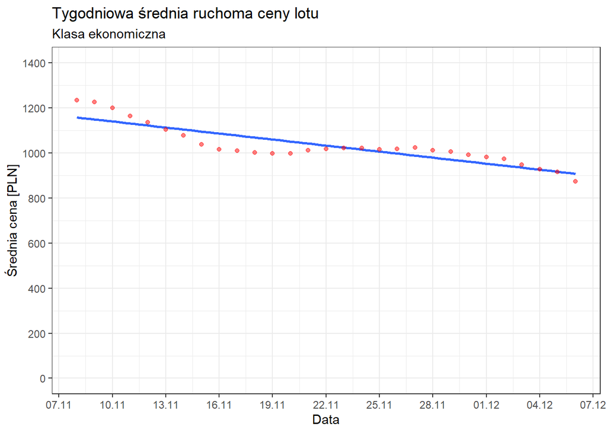

```r
dane %>%
  filter(Ticket_class == "Ekonomiczna" & Days_to_departure < 8) %>%
  group_by(Flight_date) %>%
  summarize(srednia_cena = mean(`Price [PLN]`, na.rm = TRUE)) %>%
  mutate(moving_average = rollmean(srednia_cena, k = 7, fill = NA, align = "right")) %>%
  filter(!is.na(moving_average)) %>%
  ggplot(aes(x = Flight_date, y = moving_average)) +
  geom_smooth(formula = y~x, method = "lm", se = FALSE) +
  geom_point(color = "red", alpha = 0.5) +
  scale_x_date(date_breaks = "3 days", date_labels = "%d.%m") +
  scale_y_continuous(breaks = seq(0, 1400, 200), limits = c(0, 1400)) +
  labs(
    title = "Tygodniowa średnia ruchoma ceny lotu",
    subtitle = "Klasa ekonomiczna",
    x = "Data",
    y = "Średnia cena [PLN]"
  ) +
  theme_bw()
```

Z powyższego wykresu wynika, że w analizowanym okresie ceny lotów wykazują tendencję spadkową. Można się tego spodziewać, gdyż w analizowanym okresie popyt na podróże lotnicze co do zasady spada. Oczywiście ten popyt ponownie wzrośnie w okresie świątecznym. A zatem…

### Czy w okresie świątecznym loty będą droższe?

Możemy to sprawdzić, z jednym zastrzeżeniem. Mam mniej obserwacji dotyczących cen przyszłych lotów (piszę to zdanie 6 grudnia). Zaznaczę ten fakt na wykresie, dostosowując parametr `alpha`.

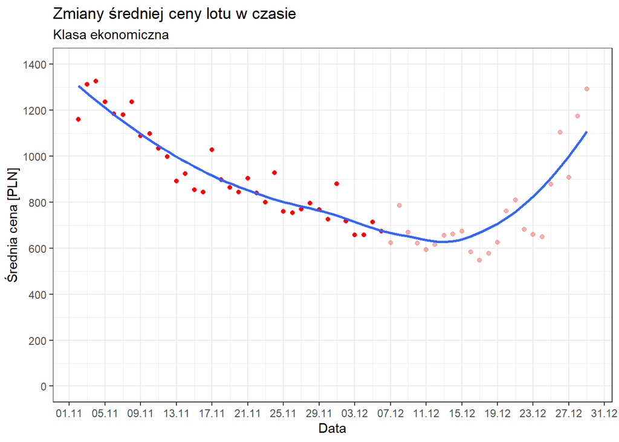

```r
dane %>%
  filter(Ticket_class == "Ekonomiczna") %>%
  group_by(Flight_date) %>%
  summarize(srednia_cena = mean(`Price [PLN]`, na.rm = TRUE)) %>%
  ggplot(aes(x = Flight_date, y = srednia_cena)) +
  geom_point(data = ~ filter(., Flight_date <= as.Date("2024-12-06")), color = "red") +
  geom_point(data = ~ filter(., Flight_date > as.Date("2024-12-06")), color = "red", alpha = 0.3) +
  geom_smooth(formula = y~x, method = "loess", se = FALSE) +
  scale_x_date(date_breaks = "4 days", date_labels = "%d.%m") +
  scale_y_continuous(breaks = seq(0, 1400, 200), limits = c(0, 1400)) +
  labs(
    title = "Zmiany średniej ceny lotu w czasie",
    subtitle = "Klasa ekonomiczna",
    x = "Data",
    y = "Średnia cena [PLN]"
  ) +
  theme_bw()
```

Rzeczywiście, ceny biletów lotniczych w okresie świąteczno-noworocznym będą wzrastać.

# Podsumowanie

Analiza wykazała, że cena biletu zależy od:

1. klasy - przeciętnie, bilet na lot klasą biznes będzie 5 razy droższy od biletu na lot klasą ekonomiczną;
2. linii lotniczej - najdroższe bilety w klasie ekonomicznej ma Air France, a najtańsze Wizz Air;
3. liczby dni do odlotu - w klasie ekonomicznej im wcześniej, tym taniej, a w klasie biznes najtaniej na 17 dni przed odlotem;
4. lotniska wylotu - z Krakowa taniej, z Warszawy-Chopina drożej;
5. destynacji - najdroższy jest Paryż;
6. dnia tygodnia zakupu biletu - tylko w przypadku biletu na lot klasą biznes;
7. liczby sztuk bagażu rejestrowanego;
8. dnia tygodnia wylotu - w klasie ekonomicznej najdrożej jest w niedzielę, najtaniej we wtorek, w klasie biznes więcej drogich lotów w poniedziałek i sobotę (skośność lewostronna rozkładu);
9. godziny wylotu i przylotu - loty poranne są na ogół nieco droższe;
10. liczby przesiadek - loty z przesiadką są na ogół droższe;
11. daty lotu (tendencja spadkowa ceny w listopadzie i 1 poł. grudnia, wzrost przed świętami)

Aby dojść do jednoznacznego wniosku odnośnie wpływu długości przesiadki na cenę biletu lotniczego, potrzebowałbym większej liczby danych / bardziej różnorodnych danych.

Bardzo ciekawe będzie zbadanie powyższych zależności dla lotów długodystansowych albo destynacji typowo sezonowych, wakacyjnych.